# Physics in the PAU, 2026: what the data now say

### 6.5.8 A rate of cohort decay, and what it can and cannot anticipate

The remaining question the coordination has put is the most ambitious: PISA measures a cohort at fifteen and the PAU measures part of the same cohort at eighteen, two years later. Between one PISA round and the next, the fifteen-year-olds get worse. Is there also a degradation *within* a cohort as it moves through Bachillerato, and if so can a rate be attached to it and used to anticipate a PAU year before it is sat?

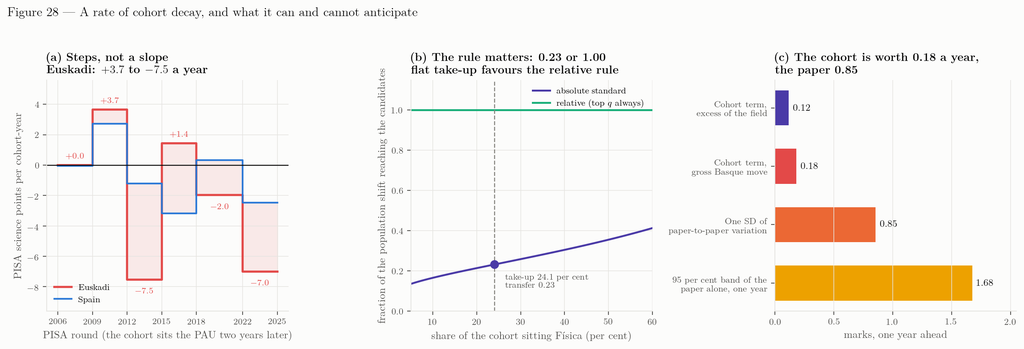

Figure 25: **a** — the change in PISA science per cohort-year between consecutive rounds, for Euskadi and for Spain; the shaded area is the Basque excess. **b** — how much of a shift in the whole population reaches a self-selected upper fraction, under a fixed ability bar and under a fixed share, against the share of the cohort that sits Física. **c** — what the cohort term is worth against what the paper is worth, one year ahead.

**The rate is not a slope.** Measured between consecutive PISA rounds, the Basque change per cohort-year runs $+0.01$, $+3.65$, $-7.53$, $+1.44$, $-1.97$, $-6.99$ points: a spread of 11.2 points a year around a mean of $-1.90$.

Table 34: PISA science per cohort-year, and what one cohort-year of the Basque excess over Spain is worth on the PAU scale. File: `data/analysis/cohort_rate.json`.

| PISA rounds | PAU years of those cohorts | Span | Euskadi, per cohort-year | Spain, per cohort-year | Excess | In marks |
| --- | --- | --- | --- | --- | --- | --- |
| 2006→2009 | 2008→2011 | 3 yr | +0.01 | -0.06 | +0.06 | +0.002 |
| 2009→2012 | 2011→2014 | 3 yr | +3.65 | +2.73 | +0.92 | +0.024 |
| 2012→2015 | 2014→2017 | 3 yr | -7.53 | -1.22 | -6.31 | -0.164 |
| 2015→2018 | 2017→2020 | 3 yr | +1.44 | -3.18 | +4.62 | +0.120 |
| 2018→2022 | 2020→2024 | 4 yr | -1.97 | +0.32 | -2.29 | -0.060 |
| 2022→2025 | 2024→2027 | 3 yr | -6.99 | -2.47 | -4.53 | -0.118 |

PISA science points per cohort-year. The Basque rates range from -7.53 to +3.65, a spread of 11.19 points a year around a mean of -1.90: the series is a sequence of steps, not a slope, and the last column is what one cohort-year of the excess is worth on the Basque PAU scale.

Two of those six intervals carry almost the whole decline and three of them are flat or positive. A straight line fitted through them has a slope, and reporting it would be a category error: the series is a sequence of steps, and the confidence band around a linear extrapolation would be an honest interval around the wrong model. There is a further practical point in the same table. The cohort that sat PAU 2026 was fifteen in the spring of 2024, between rounds, so PISA never measured it; the $-4.53$ points per cohort-year used in the budget above is an interpolation between 2022 and 2025 that assumes the fall was spread evenly over three cohorts, and nothing says it was.

**A constant within-cohort degradation is invisible, and that is the right answer rather than a failure.** Write the PAU mean of cohort $c$ sitting in year $y$ as

$$\mathrm{PAU}(c) \;=\; s\left[A(c,15) + G(c)\right] \;+\; \mathrm{sel}(c) \;+\; \mathrm{paper}(y) \;+\; \mathrm{marking}(y),$$

with $A(c,15)$ the ability PISA measures, $G(c)$ what the cohort gains or loses over the three school years, $\mathrm{sel}$ the selection into Física, and the last two terms the year’s exam and its correction. Differencing consecutive cohorts leaves $\Delta\mathrm{PAU} = s\left[\Delta A_{15} + \Delta G\right] + \Delta\mathrm{sel} + \Delta\mathrm{paper} + \Delta\mathrm{marking}$. PISA delivers $\Delta A_{15}$. It delivers nothing about $\Delta G$, which enters every difference alongside $\Delta\mathrm{paper}$ — the largest and least measured term in this dossier.

Table 35: What each term of the cohort model is, and whether PISA and the PAU together can separate it.

| Term | What it is | Observed? | Identified from PISA + PAU? |
| --- | --- | --- | --- |
| `A(c,15)` | the cohort’s ability at fifteen | yes, every three years | yes, up to the scale factor |
| `G(c)` | what the cohort gains or loses between fifteen and eighteen | no | **no** |
| `sel(c)` | who chooses to sit Física | partly: entry counts, not ability | bounded, not identified |
| `paper(y)` | the year’s exam | coded, not calibrated | **no** |
| `marking(y)` | how that exam was corrected | not published | **no** |

A constant `G` cancels in every year-to-year difference, so it is invisible *and* irrelevant to the question the office actually faces. A changing `G` would matter, and would show as the PAU falling faster than PISA for matched cohorts; it falls more slowly (-0.157 against -0.245 SD per decade, difference p = 0.67), which is no support for acceleration and, at this sample size, no refutation either.

Two consequences follow, and they are the useful part. A $G$ that is *constant* across cohorts cancels in every year-to-year difference: it is invisible precisely because it is irrelevant to the question the office faces, which is why one year differs from the next. A $G$ that is *changing* — an accelerating loss over Bachillerato — would matter, and would show as the PAU falling faster than PISA for matched cohorts. It falls more slowly: $-0.157$ against $-0.245$ standard deviations per decade in Euskadi, in the same direction as the slope comparison above already found, with the difference far from significant ($p = 0.67$) at four to six points per series. That is no support for acceleration, and at this sample size no refutation of it either.

**What transfers from the population to the candidates.** PISA measures every fifteen-year-old; PAU Física is sat by a self-selected fifth. Whether a shift in the population reaches the selected group intact depends on how the selection works, and the two natural rules differ by a factor of four. If the bar is *absolute* — a fixed standard of what a candidate must be able to do — then as the population slides down past a stationary cut, fewer qualify and the survivors are a more extreme slice, so the selected mean falls by only 0.23 of the population shift at the observed take-up. If the bar is *relative* — the top fifth sit Física, whoever they are, because that is who wants the degrees Física opens — the selected mean falls by exactly the population shift.

The evidence points at the relative rule. Under an absolute bar a declining population should produce declining take-up, and national take-up instead drifts slightly up (0.222 in 2015 to 0.240 in 2025) and shows no association with the mean at all ($r = -0.096$, $p = 0.34$ over 102 non-plateau region-years). Independently: the Basque PISA fall between 2022 and 2025 is a *location* move rather than a collapse of the top — the level 5–6 share went from 3.32 % to 1.83 %, and a uniform shift of the whole distribution predicts 1.92 %, a discrepancy of just under five per cent of the predicted share — so there is no separate thinning of the tail the PAU population is drawn from. The dossier’s one-for-one conversion is therefore defensible, but it is the *top* of the range: the cohort term it yields, $-0.12$ marks a year, is an upper bound in magnitude, and could be as small as $-0.03$. The unattributed remainder below is correspondingly a lower bound.

**The 2026 entry count runs the wrong way for dilution.** The motivated-and-unmotivated split is a real distinction and it has an observable consequence: if the share of candidates sitting Física without needing the mark rises, the mean falls with no change in anyone’s ability. In 2026 it cannot have happened, because 2 066 candidates sat Física against 2 189 in 2025 — 123 fewer, 5.6 % down. Under the assumption most favourable to the dilution story, that the ones who stayed away were the weakest, the 2026 group should have scored **0.29 marks higher** than the 2025 group on an unchanged paper. The composition change is a credit against the fall, not a part of it, and it makes the unexplained residual larger.

2025 is the opposite case and deserves the same scrutiny: 401 more candidates, 22.4 % up, on the first paper of the new structure, with a mean 0.62 lower. There, dilution is a live hypothesis — and the mark budget assigns that year almost wholly to the national component in any case, so it would be explaining a fall that is not Basque.

**What can be anticipated, then.** PISA 2025 maps onto PAU 2027 without interpolation: that cohort has been measured. The cohort term for 2027 is $-0.18$ marks against the 2026 baseline taken gross, or $-0.12$ taken as the excess over Spain, and $-0.03$ at the bottom of the transfer range. One standard deviation of paper-to-paper variation in this series is 0.85 marks, and the 95 % band from the paper alone, one year out, is 1.68. The honest summary is that a cohort projection is real, is worth about a fifth of a mark a year against a paper standard deviation nearly five times as large and a one-year 95 % band roughly nine times as large, and is therefore swamped by the choice of paper — so it belongs in the coordination’s expectations and not in its targets. If the 2027 mean comes in half a point below 2026, nothing about the cohort will have been demonstrated; if it comes in two points above, nothing about the cohort will have been refuted.

The instrument that *would* give a rate is not PISA. PISA measures every three years, which is a cadence too coarse for a question asked annually, and it stops at fifteen. What would measure $G$ is a census measure of Basque students at fifteen taken every year, bracketed at the other end by the school marks of the same cohort at eighteen — which EHU already holds alongside the PAU mark for every candidate, and which this study has for one year only (7.09 against 5.47 in 2025). That pairing, run over several cohorts, is the design that would separate a cohort arriving weaker from a cohort being taught and examined differently. It is item 8 below.

### 6.5.9 What can be subtracted, and what cannot

Panel c of Figure 20 subtracts from that 1.65 everything the dossier can put a defensible number on, and leaves the rest visible.

Table 36: Components of the 2025 → 2026 Basque change, with the status of each and the measurement that would separate it from the others. File: `data/analysis/decomposition_components.csv`.

| Component | Marks | Range | Status | What would identify it |
| --- | --- | --- | --- | --- |
| Common to the country | +0.17 | — | observed | already separated: it is the field’s own move |
| Choice removed from the paper | -0.20 | -0.27 to -0.10 | quantified (modelled) | option-level marks: the realised premium is observable directly |
| Cohort (PISA-implied) | -0.12 | -0.23 to -0.01 | quantified (modelled) | nothing further inside the PAU; it is an outside measurement |
| Paper content and reading load | not quantified | — | not identified (collinear) | sub-task marks: where in the paper the marks were lost |
| Marking severity (penalty list, voided sections) | not quantified | — | not identified | sub-task marks and the penalty ledger |
| Tribunal severity and spread | not quantified | — | not identified | Física by tribunal: n, mean, SD, school composition |
| Syllabus exposure (newly examined topics) | not quantified | — | not identified (bounded) | option take-up rates and per-option means |
| Who sat the exam | not quantified | — | not identified (bounded small) | enrolment and the school marks of the 2025-26 cohort |

Two components can be quantified, and both have to be expressed as differences *from the field*, because the quantity they are subtracted from is one. **Choice** removed from the paper is worth $-0.26$ marks of expected score by simulating the two Basque formats on the same population and the same items; but the other eight communities cut optionality by 6.25 points on average and whatever that cost them is already inside the $+0.17$, so the part that belongs here is about **$-0.20$** ($-0.10$ to $-0.27$ over item spreads of 0.1 to 0.3). **The cohort** is the Basque PISA decline *in excess of Spain’s* — 13.6 of the 21.0 points — which is about **$-0.12$** for one PAU year at one standard deviation for one standard deviation. Together: **$-0.31$**, under a fifth of the Basque-specific fall.

Both terms are modelled, and their ranges are sensitivities to one assumption each rather than intervals. The choice term assumes an ability distribution, an item-noise scale and independent item errors, and it prorates the field’s cuts linearly because the other formats were not simulated. The cohort term’s $\pm 0.11$ covers PISA’s sampling error and nothing else — not the one-for-one transfer, which figure 22 could neither reject nor establish, not the PAU standard deviation imported from another community, and not the interpolation across cohorts that PISA does not measure. They are defensible magnitudes under stated assumptions, not measurements.

The remaining **$-1.33$, four fifths of it, is not attributed to anything**, and the honest reason is that the four candidates for it cannot be separated from one another with published data. The share is not a precise quantity either: it is the complement of two modelled terms inside a residual that is itself a difference of two noisy averages, and a tenth of a point either way in the field’s 2026 mean moves it by about six points. Paper content and reading load are one signal seen twice, correlated at $+0.79$ across eight communities; taken literally the cross-community relation between length and grade change would assign 2.3 marks to the Basque paper’s 45 % lengthening, which is more than the entire Basque-specific fall and is itself the reason not to take it literally. Marking severity is documented as a set of rules and nowhere as a number of marks. Tribunal severity was computed by EHU and not published. Newly examined topics sat in optional slots in June, which bounds their effect but does not measure it.

Three things follow, and they are the practical content of this chapter.

The first is that **the unexplained part is the finding**, not a gap in the write-up. Four fifths of the Basque-specific fall sits in a bundle of four mechanisms that the published aggregates cannot prise apart, and no amount of further work on those aggregates will change that. Only data at the level of the script — which exercise, which option, which sub-task, which tribunal — separates them. That is why the requests below are ordered as they are.

The second is that **the components that can be separated are small, and the ones that matter are the ones nobody has measured**. Choice and cohort together are less than a fifth of the problem. A coordination discussion that spends itself on optionality is arguing about the part of the fall that is already understood.

The third is that **2024 and 2026 may be one mechanism or two**, and the same data would decide. A compression at the top in 2024, on the old paper, and a collapse of the level in 2026, on a new one, are compatible with a single slow change in what the marking rewards; they are equally compatible with two unrelated events. The tribunal table covers 2025 and 2026 and would show whether the severity that is visible in 2026 was already building; the 2024 and 2025 histograms, which EHU holds, would show whether the 2024 compression was general or confined to some panels.

## 6.6 The statement, item by item

The reading-load section measures one paper against another: the Basque statement grew 45 % between 2025 and 2026, the strongest cross-community correlate of the grade change in this study and also the weakest causally. A paper-level number cannot say *where* the growth is, and “where” is the only form in which the finding can be acted on, because a paper is written one problem at a time.

This section measures each item separately, in both Basque papers, on one convention; then reads the design analysis the coordination itself has carried out on the 2026 electromagnetic problem, and says what the dossier can and cannot add to it.

**A conflict of interest, stated**

The design material used below comes from a coordination presentation of which the author of this dossier is a co-author. Its word counts have been recomputed here from the archived paper and can be checked; its account of *why* the 2026 statement was written as it was cannot be, and is testimony — the same evidence class as the rest of the coordinator’s account of unpublished decisions Ch. 14. Nothing in this section rests on that account being true; what it does is make the account falsifiable, by naming a comparison inside the marked scripts that would support or contradict it.

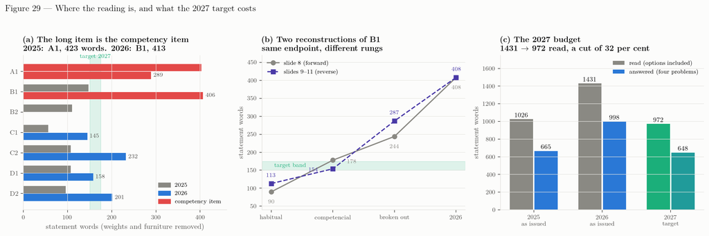

Figure 26: **a** — each item’s statement, 2025 and 2026, against the 2027 target band; the obligatory competency items are in red. **b** — the two reconstructions of problem 2, which share only their endpoint. **c** — what the paper costs a candidate to read and to answer, and what the 2027 target would cost.

### 6.6.1 Where the reading is

Table 37: The two Basque papers measured statement by statement. File: `data/analysis/statement_budget.csv`.

| Paper | Statements printed | Words read | Words answered | Longest statement | Furniture | Whole paper |
| --- | --- | --- | --- | --- | --- | --- |
| EHU 2025 | 7 | 1026 | 665–764 | A1, 403 | 356 | 1382 |
| EHU 2026 | 6 | 1431 | 998–1128 | B1, 406 | 398 | 1829 |
| **Target 2027** | 6 | 900–1050 | 600–700 | 150–175 each | (unchanged) | ≈ 1370 |

Statement words only, weights and page furniture removed; every column on one tokenisation, so that furniture plus statements equals the whole paper. “Words read” counts every statement a candidate must read, options included; “words answered” the cheapest and dearest route through the options. Furniture is the instruction header, the constants table, the block headings and the printed weights. The whole-paper figures of Figure 14 are 1 335 and 1 940 on a word-token count rather than this whitespace one, and the $+45$ % of that figure is computed on it throughout. The target row assumes the 2026 furniture unchanged. File: `data/analysis/statement_budget.csv`.

Two facts come out of the item-level count, and neither is visible in the paper total.

**The length lives in the competency items, and it did so in 2025 as well.** In 2025 the paper printed seven statements; six of them run 56 to 147 words, and the seventh — A1, the single obligatory competency exercise — runs **403**. One item carried 39 % of everything a candidate read. In 2026 there are two obligatory competency exercises, A1 at 289 and B1 at **406**, and between them they carry 49 %. The four optional items average 184 words against the 2025 options’ 104, so the whole paper did get wordier; but the extreme values are the competency items in both years, and of the 405 words the paper gained, B1 alone — an item that did not exist in 2025 in this form — accounts for more than the whole net increase, A1 having *shrunk* by 114.

**Part of the growth is not questions at all, and part of it is bookkeeping.** Statements went from 1 026 to 1 431 words, $+39.5$ %. The furniture — instruction header, constants table, block headings, printed weights — went from 356 to 398, barely moving in total but changing entirely in composition: the block headings fell from 101 words to 54, and **103 words of printed sub-task weights appeared where the 2025 paper had none**. The 2026 paper prints a weight fifty-one times, eighteen at part level and thirty-three on sub-tasks; the 2025 paper prints none at all, carrying only the global “2.5 puntos” in its instructions. The granular rubric is an improvement for the candidate; printing it fifty-one times inside the running text is not the only way to deliver it.

The second is that the $+45$ % of the reading-load section and the $+39.5$ % here are *not* the same quantity measured twice. The first is the whole file on a word-token count; the second is the statements alone on a whitespace count. Both are reported, neither is corrected by the other, and the furniture figures in the table are computed on this section’s tokenisation throughout so that statements plus furniture equals the whole paper within the table.

The third is a small migration the convention cannot help creating. The 2025 paper prints its constants inside the three statements that need them, 21 words in all; the 2026 paper moved every constant to one table for the whole paper, which this convention counts as furniture. About twenty words therefore cross the statement/furniture line for reasons of layout alone. It is small enough not to change anything above, and it is the kind of thing that would matter if the two papers had been more alike.

### 6.6.2 The trajectory, and why the budget has two tiers

One consequence of the item-level count deserves its own section, because it is the hardest part of the 2027 plan and it is invisible in the paper total.

**A competency item costs about 400 words in its first year and about 300 in its second.** That is not a guess; it is what the two Basque papers show, and it shows it twice. Block A entered the competency form in 2025 and its item ran **403** words; in 2026, its second year, the same block ran **289**. Block B entered in 2026 and its item ran **406** — the same figure as A’s first year, to within three words. The coordination’s target for 2027 is **250** for both.

Table 38: The cost of a competency item over its first years, in statement words [`data/analysis/statement_budget.csv`].

[output not shown]

Read that way the 2026 paper is not a paper that went wrong; it is a paper carrying one block at 400 and another at 300 in the same year, which is what the transition costs when blocks enter one at a time. It also says the 250 is reachable: A has already done 403 → 289, a cut of 28 %, and needs 13 % more; B is being asked for 38 % in one step, which is steeper than A managed but of the same order.

**But 250 and the 150–175 band do not fit in the same paper.** The budget is six statements. Two of them are competency items and four are options, and they are different animals:

Table 39: Two tiers against one band.

|  | two competency items | four option items | total read |
| --- | --- | --- | --- |
| 2026, as issued | 289 + 406 = 695 | 4 × 184 = 736 | **1 431** |
| 250 each, options unchanged | 500 | 736 | 1 236 |
| 250 each, options at 175 | 500 | 700 | 1 200 |
| **250 each, options at 150** | **500** | **600** | **1 100** |
| 250 each, options at 118 | 500 | 472 | 972 |
| a uniform 150–175 band | 300–350 | 600–700 | 900–1 050 |

The last two rows are the choice. A **uniform** band of 150–175 per statement implies the competency items come down to 150–175 as well — far below the 250 the coordination itself thinks right, and below the 154 of the compressed version it calls the hardest to read. Keeping 250 and putting the options at 150 gives a paper of about **1 100 words read**, a cut of 23 % rather than 32 %.

The recommendation that follows is to state the budget in **two tiers rather than one band**: competency items at or below 250, option items at or below 150, and the paper total as a check at about 1 100. It is coherent with the trajectory the papers already show, it does not ask the competency items to do something the coordination believes is pedagogically wrong, and it puts the saving where the evidence puts the growth.

One further point, and it argues against cutting the options harder than 150. The C and D items are still in the old style, and they are read in full by every candidate who has an option. They could be compressed further — 118 is arithmetically available — but they are the next blocks due to enter the competency form, and every word taken out of them now will have to be put back when they do. Cutting them to the bone in 2027 would buy a number this year and a second transition shock later.

### 6.6.3 Four versions of one problem

The 2026 electromagnetic problem, B1, was not written in one pass, and the coordination has reconstructed the passes. As issued it is 408 words on its own count. Stripped of its narrative it is 287. Written in the compressed form the competency model would license, 154 — 170 if it also asks the candidate to draw the two configurations. Written the way the block was examined before the competency requirement, 153 with the set-up in prose and **113 with the set-up as a figure**.

The coordination’s account of the 2026 design is exact and worth recording as a structure rather than as a sentiment: **three habitual calculations, asked twice — once per configuration — and three competency elements, asked once.** The habitual three are the flux $\Phi(t)$, the induced e.m.f. $\varepsilon(t)$ and its value at $t = 7.0$ ms; the competency three are justifying that the angle between $\vec{B}$ and $\hat{n}$ is constant, expressing the result in scientific notation to two decimals, and deciding whether the prototype meets the sensor’s requirement. That structure is verifiable and has been verified against the paper line by line. The *reason* given for it — that block B entered the competency paradigm for the first time in 2026, and that the repetition was meant to carry candidates through the new demand by rehearsing the familiar part twice — is testimony, and is recorded as such.

A note on the reconstructions in panel b of Figure 26, because a reader who meets both will notice. There are **two** ladders, not one, and they are two different exercises rather than one exercise measured twice. The forward account of slide 8 begins from a statement the coordination wrote for the purpose — an old-style problem in the pre-competency manner, 90 words — and builds it up to what was issued: 90 → 178 → 244 → 408. The reverse account of slides 9 to 11 starts from the paper as it went out and works backwards: 408 → 287 → 154 → 113. They share only their endpoint, and their rungs differ by 23, 24 and 43 words. Neither is wrong; they answer different questions, and anyone presenting both should say which is which, because a reader who takes slide 8’s first rung and slide 11’s last for the same object sees 90 and 113 for “the habitual statement”.

The two ends of the reverse ladder are also not the same kind of object, and the difference is the point of the exercise. Its last rung, 113 words, is the old style **with the configurations given as a figure**, which is how they were given before the competency requirement: a sketch of the loop, $\vec{B}$, $\hat{n}$ and the axis, instead of two paragraphs describing them. The competency form has to put that back in words, or ask for it. That contrast — a drawing given away against a drawing demanded — is the coordination’s own, and it is the most transferable thing in the four slides.

### 6.6.4 What the dossier can add, and what it cannot

Three observations, of which the second is the one this study could not have reached on its own and the third is a test it can now specify.

**The scaffolding is symmetric, and symmetry is where the words are.** A caution first, because an earlier version of this section put it too strongly: b) and c) are not the same calculation. Configuration I is a stationary loop in a field whose magnitude varies as $3t^2$; configuration II is a loop rotating at constant $\omega$ in a constant field. The flux, the derivative and the numbers are different, and so is the physics a candidate has to see. What repeats is not the calculation but the **structure of the demand**: write $\Phi(t)$, deduce $\varepsilon(t)$, evaluate at $t = 7.0$ ms, told twice, sub-task by sub-task.

That structure is what costs the words, and it is what can be spent once instead of twice. Asymmetric scaffolding — break the chain out in configuration I, compress it to “deduce $\varepsilon(t)$, calculate, decide” in configuration II — spends the words once and leaves the candidate to supply the intermediate steps the second time, on a genuinely different situation. That is the competence the paradigm is after, and it is a real increase in demand rather than a saving dressed up as one. None of the four reconstructed versions is that form, so it has no measured length; it must sit between the 154 of the fully compressed version and the 287 of the symmetric one, and nearer the first.

It is also not the only candidate. The coordination’s own proposal — the last rung of the reverse ladder, the old style with the configurations drawn and the drawing then demanded back in the competency version — reaches 113 and 170 words respectively and solves the same problem from the other end. **Both should be put to the teachers as candidates**, because they trade differently: the figure buys space without changing what is assessed, and the asymmetry buys space by asking for more.

**One of the three “competency elements” is a transversal criterion, not a competence — and it was put there deliberately.** “Express the result in scientific notation and with two decimals” is not on the four-level ladder the coordination itself uses: *conocer* (escribe, enuncia), *comprender* (explica, justifica), *aplicar* (calcula, deduce), *valorar* (compara, decide). It belongs to *saber básico* A, the transversal block, and it applies to every numerical answer in the paper whether or not it is printed.

What the coordination did in 2026 was print it, and attach points to it, because 2026 was the first year it was examined explicitly as the criteria require — the intention being to tell candidates that it counted rather than to catch them out. That is a defensible piece of scaffolding and it is not the taxonomy error an earlier version of this section called it. The coordination’s own reading is that it should not have been coloured as a competence in the presentation, and that nothing of the kind will appear in the 2027 paper: the criterion will be enforced from the rubric, where it always applied.

It still matters here, for two reasons that survive the reframing. It costs words in the statement for a demand that exists anyway. And in 2026 it created a sub-task in which the *same requirement* was both awarded points when met and deducted at $-0.10$ when missed — which is a concrete, locatable instance of the confound the severity section can bound statistically but not separate. In B1 the competency wording and the deduction sit in the same sub-task, so no treatment of aggregates will tell them apart; only reading the marked scripts will, and it is one of the things the tally should look at.

**The item that grew most is the item whose growth was deliberate — and there is a sharp test of whether it worked.** B1 is 406 of the 1 431 words a candidate reads, 28.4 %, for 25 % of the marks. Whether its expansion helped or hurt cannot be settled by the cross-community length association, which is post-hoc and leveraged by this very paper. It can be settled inside the sub-task marks, and the comparison has to be drawn carefully. Part b) spends its whole 1.00 on the chain, in three sub-tasks of 0.25, 0.25 and 0.50; part c) spends only 0.50 on the same chain and the other 0.50 on deciding whether the prototype meets the requirement, which is a *valorar* task with no analogue in b). **The clean comparison is therefore b)’s three sub-tasks against c)’s first, per mark, on the same chain in a different configuration**: if the repetition worked as the scaffolding it was designed to be, c)1 should score above b)1–3; if it was a time tax on the longest statement in the paper, below. Comparing the two parts whole would confound the answer with how hard the evaluation sub-task turned out to be. That comparison is now the first sub-question of request 1, and B1 is the item on which to run it first.

### 6.6.5 What a budget costs

The coordination’s 2027 target as the presentation states it is 150 to 175 words per statement, mean 162: 900 to 1 050 words read against 1 431 in 2026, and 600 to 700 answered against 998 to 1 128 — a cut of about a third in reading and of 35 to 43 % in answering, depending on which options a candidate takes. The two-tier version above relaxes it to about 1 100 read, a cut of 23 %, by letting the competency items keep 250 words each. The rules below deliver either; the difference between them is a policy choice about how much to ask of the two obligatory items in the second year of the transition.

Placed against the two measured papers, the uniform target is **not** a return to 2025. The 2025 paper’s actual mean was 147 words per statement and the 2026 paper’s 239; the target’s 162 sits fifteen words above the first and seventy-seven below the second. On the whole-paper convention the target maps to about 1 370 words, inside the 1 300–1 400 band the briefing’s fourth design lever recommends.

Those two targets should not be called independent, and an earlier version of this section did. Both are anchored to the same object: the briefing’s band was set as “a target near the Basque paper’s own 2025 length”, and the coordination’s 162 is the 2025 paper’s own per-statement mean plus an allowance. They agree because they were both derived from the 2025 paper, not because two lines of evidence converged. What is worth something is the *form*: the lever is now stated **per statement**, which is the unit a setter can act on, with the whole-paper figure kept only as a check — and a fifteen-word gap between two conventions is inside the noise of the conventions themselves, so no weight should be put on its size.

Five rules follow, ordered by the words they save on the 2026 paper.

1. **Write the context as data, not as a story.** The coordination’s own rewrite takes B1’s context and configurations from 156 words to 76 with nothing lost — the weather station, the isolated valley and the engineering team carry no physics. Across four problems this is the largest single saving available.
2. **Print the set-up as a figure.** Replacing the two prose descriptions of the configurations with two diagrams takes the habitual version from 153 to 113 words, and a diagram carries the geometry — $\vec{B}$ along $+OZ$, $\hat{n}$, the rotation axis $OY$ — better than any sentence, which matters for a cohort whose measured reading has fallen three times as fast as its science. The rule has an exception worth stating as a rule of its own: *a figure that shows the set-up is a gift, so if the set-up is what you want to assess, ask for the drawing instead of printing it.* Asking for it costs sixteen words and converts a gift into a competency element.
3. **Scaffold once, not twice**, as above.
4. **Move marking criteria out of the statement**, and print the sub-task weights in a margin column rather than in the running text: 103 words on the 2026 paper, with no change to anything a candidate has to do. This one does not come out of the 1 431, because the weights are furniture and were never inside it; it is a saving on top of the target, not a contribution to it.
5. **One verb per level per problem, not per sub-task.** In B1 as issued, *indica* appears four times, *escribe* three, and *calcula*, *deduce* and *expresa* twice each. The four-level ladder needs each level present in the problem, not in every part of it.

None of this is evidence that statement length caused the 2026 fall, and the chapter should not be read as saying so. The item-level count locates the reading; it does not weigh it. What the five rules have going for them is that they are cheap, that they are reversible, that four of the five remove words without removing a demand, and that the fifth — scaffolding once instead of twice — replaces a rehearsal with a transfer, which is a gain in what is assessed and not only in what is read.

## 6.7 The institutional record since 6 July

- **6 July**, EHU: Física figures published as a counter-example in the Euskara controversy; tribunal data handed to the Education Department; anomalous tribunal values reported for eleven subjects including Física (Argia, 2026; Euskal Herriko Unibertsitatea, 2026a).
- **7 July**, Science and Universities Counsellor: admits a “déficit de confianza, fundamentado o no fundamentado” in the marking system; floats multi-marker models; ≈ 40 judicial appeals by students with very low marks.
- **7 July**, extraordinary sitting: 71.4 % global pass, 1 332 presented (83.2 % in July 2025, 90.6 % in July 2024); no Física figure.
- **8–10 July**: 12 000-signature faculty manifesto in support of markers; EHU appeals the court measures on the Euskara marks; press notes that “los ceros en Física duplican a los de Euskera”.
- **12 July**, Education Counsellor Pedrosa (Alonso, 2026): the Department has only the EHU report, will request more data, will review all subjects for 2027 “a corto plazo”, has no diagnosis yet, and does not hold other communities’ data.
- **30 July**, Galicia (context): after errors in three papers, the Xunta announces peer review of papers and double marking for 2027 — the single-author, no-external-review failure mode that any Basque audit should check for.
- **7 September**: nothing sent to schools for PAU 2027 beyond the Euskara II instructions; “2027 será un año de ajuste técnico” and the competency model is to be fully deployed in 2028.

## 6.8 What to ask for, and what each request would separate

The list below is ordered by how much of the unattributed $-1.33$ each item would resolve, not by how hard it is to obtain. Each request names the component of Table 36 it identifies, so that a request that is refused can be traded against another rather than simply dropped. Items 3 and 8 came out of earlier rounds: the first out of taking the marking-severity hypothesis seriously enough to ask what would test it, the second out of asking what instrument could give a cohort rate that PISA cannot. Item 11 is new in this round, and it came out of a mistake — the dossier had been reading its own modelled top band as though it were published, and correcting that turned a supposed failure of the marking model into the sharpest single measurement on the list (the shape section).

1. **Sub-task marks for a sample of 2026 scripts** — mean and distribution of the marks awarded on each numbered sub-task of each exercise and option, on a stratified sample of, say, 300 scripts across tribunals. *Separates*: paper content, reading load, marking severity and syllabus exposure — all four of the unattributed components at once, because each leaves a different signature. Marks lost in the two obligatory competency exercises and not in the options point at content; marks lost in the explain-and-evaluate sub-tasks and not in the calculations point at genre; marks lost through accumulated $-0.1$ penalties and voided sections point at the marking scheme; marks lost only by the candidates who chose the newly examined options point at exposure. This is the single request that would turn three quarters of the fall from a bundle into a set of numbers, and it is what the Canarian subcommittee planned to do for its own 2026 paper. **Run it first on B1, and run one comparison before any other**: b)’s three sub-tasks against c)’s first, per mark. Both are the same three-step chain in a different configuration, so if the repetition worked as the scaffolding it was designed to be, c)1 should score above b)1–3; if it was a time tax on the longest statement in the paper, below. The two parts must not be compared whole, because half of c) is an evaluation sub-task with no analogue in b). Nothing else in the request is as cheap to compute or as directly actionable (the statement section).
2. **Física by tribunal, 2025 and 2026** — $n_j$, $\bar{x}_j$, $s_j$ and the school composition of each tribunal’s scripts. EHU computed this table and published the equivalent for three other subjects. *Separates*: tribunal severity from everything else, and shows whether the severity visible in 2026 was already building in 2025.
3. **The deduction tally, 2025 and 2026, for Física, Matemáticas II, Lengua Castellana and Euskara II** — how many scripts lost the 0.2 linguistic component, how many $-0.10$ minor-error deductions were applied per script broken down by the seven types, **how many scripts had at least one apartado voided for a grave error, and how many apartados were voided in those scripts**. The last two matter as much as the first: the regime section shows that the deduction channel alone cannot produce a single zero, and that the voiding channel can reproduce the whole 2026 distribution if and only if it cascades within a script. The three numbers the model needs are about twelve deductions per script, a grave error in one script in six, and 85 % of that script’s apartados voided; the tally either finds them or it does not. *Separates*: general marking severity from the quantitative-specific kind, which is the distinction the severity section can bound but not measure. This is the cheapest decisive request on the list. It collects nothing new: the deductions were recorded when they were applied, the four subjects are already marked, and the comparison the coordination wants — is the second year stricter than the first, and is it stricter in the same way for a physics script as for a language script — falls straight out of two cross-tabulations. If any single item on this list can be obtained quickly and from inside the university, it is this one.
4. **The full Física grade histogram, 2024, 2025 and 2026**, in one-point bands with the zero and ten counts, as the two Canarian universities publish routinely. *Separates*: location from shape in 2026 — the one classification this chapter could not make — and lets the 2024 compression be checked against the 2024 and 2025 shapes directly rather than through the band aggregates.
5. **Option take-up in 2026**: how many candidates chose each of 3a/3b and 4a/4b, and the mean of each. *Separates*: syllabus exposure from paper difficulty, and measures the realised choice premium against the $-0.26$ this study simulates.
6. **July 2026 Física**: presented, passed, mean. *Separates*: whether the June pitch was specific to that paper or a standing property of the 2026 marking, since July is a different paper marked under the same rules.
7. **Revision statistics for Física 2026**: requests, share raised, mean change. Published for four subjects and not for the one with the lowest mean. *Separates*: marking severity, weakly but cheaply — a high raise rate is evidence about the first marking.
8. **The school mark and the PAU mark, paired, for every Física candidate of the last five cohorts**, with sex, language and territory, and the enrolment figures the annual reports carried until 2022. *Separates*: two things at once. Cross-sectionally it measures who sat the exam, which the entry-count argument currently bounds rather than measures. Over cohorts it is the only instrument available here for $G(c)$ — the school mark and the PAU mark are two measurements of the same students taken weeks apart against two different standards, so a widening gap is either the standard moving or the cohort’s preparation not being what the school mark says it is, and the two can be told apart by whether the widening is common across subjects. This study has the pair for one year only (7.09 against 5.47 in 2025) and can therefore say nothing about its trend.
9. **The 2026 papers and marking criteria of the other eight communities, with their published means**, and if it exists the text that fixes the structural criteria nationally. *Separates*: nothing inside Euskadi, but it decides how much weight the field comparison can carry. Chapter 11 codes the nine papers and finds them markedly different in the direction each moved in 2026; what it cannot do is say whether every community was *required* to move as Euskadi moved, because the binding text is not in this study’s source registry. Until that is settled, the $-1.65$ is a comparison with communities that did something different, not with a control group.
10. **The record of the correctors’ meeting held before the 2026 sitting**: the agenda, the attendance, and the criteria document circulated at it. *Separates* nothing by itself, but it is what turns the account of the regime change from testimony into record — that the full application of the deductions was agreed collectively, and when. It costs nothing to retrieve and it is the difference between a mechanism the dossier reports on one person’s word and one it can cite (the regime section).
11. **The 2026 grade-band table for Física — the share of scripts in $[0,5)$, $[5,6)$, $[6,7)$, $[7,8)$, $[8,9)$ and $[9,10]$** — the same table Euskadi published every year through 2025 and has not published for 2026. *Separates*: the shape of the penalty distribution, and with it how much of the fall the marking regime can be held to account for. The shape section refits seven readings of the same regime against the four figures that *are* published; all seven match them, and the five that are readings anybody has offered differ by a factor of twenty-three on the share at or above nine — from 0.3 % if the penalties fell evenly on everybody to 6.1 % if they concentrated on the weakest. That single number therefore decides whether the marking sheet carries 87 % of the Física-specific $-1.10$ or 59 % of it, which is the difference between a dossier that has explained the Física fall and one that must keep looking. The dossier’s own $2.09$ % is a smooth-curve extrapolation and is labelled modelled throughout; it is not a substitute. This is the cheapest request on the list — the table is a by-product of a tabulation already run, and it was routine until last year.

Requests 1 to 4 are the ones that change what can be concluded, and request 11 is the one that costs least for what it settles. If only one can be obtained, it should be the first; if the first is refused as too laborious, a re-marking of a stratified sample by a second panel would substitute for both 1 and 2 at the cost of the marking itself. Request 3 is the exception to the ordering, in that it is the only item that is both decisive for one component and obtainable within days.

## 6.9 The memory of the panel, and the one prediction 2027 can settle

This section exists because of a question about a picture. Looking at Cataluña’s position against the field over 2015–2025 (the event study), the coordination asked whether the curve was cyclic, and what might be driving it. Testing that properly required measuring something the dossier had never measured — how much memory these series have — and the measurement turns out to matter more than the question that prompted it.

### 6.9.1 The wave is not a cycle, and the reason is structural before it is statistical

The fit is real enough: the best sinusoid on the eleven points gives $R^2 = 0.826$ at a period of **8.6 years**. Four things dispose of it.

**A difference cannot contain a common driver.** The plotted quantity is one community *minus the field*. Anything acting on every community at once — a national reform, the pandemic, a demographic wave — is removed by that subtraction by construction. Whatever the wave is, it cannot be an external force acting on Spain; it would have to be specific to one community and carry a nine-year clock.

**Eleven annual points contain one cycle.** The frequency resolution of an eleven-year record is $1/11$ yr$^{-1}$, so a period near nine years is not distinguishable from infinity — that is, from a trend, or from no cycle. Three cycles, the conventional minimum, would need about thirty years.

**The null decides the answer, and the obvious null is the wrong one.** Against white noise the fit is significant at $p = 0.02$. Against the *pooled* AR(1) coefficient of the panel, $\phi = 0.61$, it is not ($p = 0.14$) — but that coefficient is mostly *between* communities, several of which sit above the field every year, and because the sinusoid fit carries a constant a community’s own level is absorbed and cannot affect $R^2$. The null that governs the shape is the **within-community** process, $\phi = 0.186$ ($0.305$ after correcting the downward Nickell bias of a short dynamic panel). On that null the false-alarm probability is $0.024$ to $0.042$: marginal, and alive.

**So the look-elsewhere effect decides it.** One series was examined because it looked wavy; the same fit was therefore run on all fifteen.

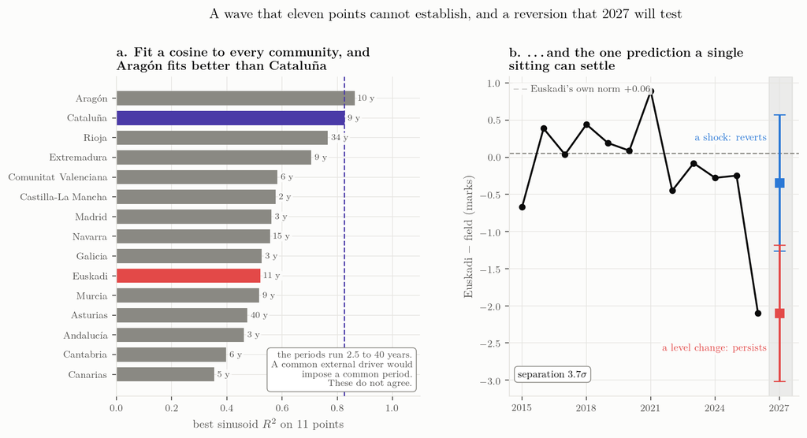

Figure 27: **a** — the best sinusoid fitted to every community’s deviation from the field, eleven points each, with the recovered period printed against each bar. **b** — Euskadi’s position against the eight communities that published a 2026 figure, with the two predictions for 2027.

### 6.9.2 What the appearance actually is

The within-community coefficient explains it completely. For an AR(1) process the year-to-year *changes* anticorrelate at $-(1-\phi)/2$:

$$\text{predicted } \operatorname{corr}(\Delta_t, \Delta_{t-1}) = -0.407,
\qquad \text{observed } -0.389 \;\; (p = 3\times10^{-6},\; n = 135).$$

A year that moves down tends to be followed by a move up, at exactly the rate mean reversion alone predicts. No feedback loop, no external forcing and no cycle is needed. The wave is what mean reversion looks like over eleven years.

### 6.9.3 The consequence: what 2027 will do by itself

Measured against the eight communities that published a 2026 figure, Euskadi’s norm over 2015–2024 is $+0.06$. In 2025 it sat at $-0.25$; in 2026 at $-2.10$. Its 2026 deviation from **its own norm** is therefore $-2.16$, and the panel’s innovation standard deviation is $0.47$.

Table 40: The two readings of 2026, stated before the sitting. File: `data/analysis/cycle_and_reversion.json`.

| 2027, if the 2026 fall was… | expected deviation | 95 % interval |
| --- | --- | --- |
| a transient **shock** | $-0.40$ ($-0.66$ bias-corrected) | $[-1.32,\ +0.52]$ |
| a permanent **level change** | $-2.16$ | $[-3.08,\ -1.24]$ |

The predictions differ by 1.76 marks against an innovation sd of 0.47 — **a separation of 3.7 $\sigma$, settled by one sitting.**

**And this is the warning the section exists to deliver.** If the paper is changed for 2027 and the mean recovers by about a mark and a half, *that is what the panel predicts from doing nothing at all*. A recovery of that size is not evidence that the intervention worked; only a recovery clearly beyond the reversion band would be. Written here before the sitting, which is the only time such a statement is worth anything.

The honest caveat is that the shock branch assumes 2026 was a draw from the same process. If the instrument is permanently different, that assumption fails — which is precisely the alternative the test discriminates.

## 6.10 Design questions for 2027 that the data already inform

- **Optionality.** The 2026 Basque paper fixed problems 1 and 2 with no alternative (optional share 75 % → 50 %). The COVID years (single super-option, choice among questions) produced the highest means in the series; the 2025–26 reduction of choice coincides with the two lowest. But choice alone does not set the direction, and a second verification pass corrected this chapter on the point: Canarias cut optionality by 30 points and fell, while Castilla-La Mancha cut it by the same 30 points and rose $+0.94$, having spent the recovered space on a single obligatory contextualised item and changed nothing else (Chapter 11). Restoring a choice *within* problems 1–2 is the cheapest lever with a documented effect on the expected mark; it is not a guarantee of one on the outcome.
- **A statement budget, in two tiers.** The unit a setter can act on is the item, not the paper, and the two kinds of item are not alike: a competency exercise has cost about 400 words in its first year and 300 in its second, an option item about 150 to 185. A budget of **250 for a competency item and 150 for an option** gives a paper of about 1 100 words read against 1 431 in 2026, a cut of 23 %, and is consistent with the trajectory the Basque papers already show (block A went 403 → 289 unaided). A uniform 150–175 band across all six statements would give 900–1 050 but would require the competency items to do something the coordination believes is pedagogically wrong. A further 103 words sit outside either total in the furniture — fifty-one printed weights the 2025 paper did not carry — and can go without touching a question. The five rules that deliver the cut are in the statement section.
- **Calibration against a reference.** The Ministry cube gives, for every subject, community and year, a full distribution; a target distribution for Física (for example the 2017–2024 Basque band structure outside the COVID peak, $[0,5)$ ≈ 30 %, $[9,10]$ ≈ 16 %) can be written into the coordination instructions and checked against a pre-test of the paper on a sample of Bachillerato students, as some communities’ ponencias already do informally.
- **The threshold.** At the ULL the customary bunching of scripts just above the pass line thinned in 2026, from 17.5 % of scripts in $[5,6)$ in 2024 to 11.9 %; at the ULPGC, which never had the same bunching, it did not move (12.6 → 12.8 %). Whether borderline rounding is wanted is a policy question; at the ULL it was worth about 5.6 points of pass rate, and whether EHU rounds at all is not published.
- **Order of exams.** Física is sat on the last slot of the science day in several communities; the Tenerife minutes name this explicitly. The Basque timetable is a free parameter, and it was moved between 2025 and 2026 without, as far as any published record shows, being treated as one: Matemáticas II came out of the morning and into the slot immediately before Física, so that the two heaviest quantitative papers were sat back to back for the first time (the calendar comparison). The partition of the 2026 subject changes follows that pairing exactly, and is confounded with it beyond separation. Two decisions cost nothing and remove the confound for 2027: do not schedule Matemáticas II and Física consecutively, and do not schedule Física in the slot after the subject that competes with it for the second weighted mark. If the pairing is kept, the 2027 result will again be uninterpretable on this axis.
- **Second marking.** Galicia’s 2027 reform (double marking, external review of papers) is the model that the “déficit de confianza” language of July points toward; Veas & López-Pina’s Rasch equating in Comunitat Valenciana is the statistical complement.

# 7 The papers themselves

*How competency-oriented were the 2025 and 2026 Física exams in the communities that rose and in those that fell?*

## 7.1 The question

The comparative chapters establish that between 2025 and 2026 the Física mean rose in six of the nine communities with a published figure and fell in three, Euskadi most of all. One reading of that pattern, put forward when this chapter was commissioned, is that the Basque paper moved further towards the competency model than the others: in 2025 the EHU paper had one competency-style exercise out of four blocks; in 2026 it had two obligatory competency exercises out of four, that is half of the marks. If the communities that rose did not move at all, the “competency” label would be doing very different work in different places, and the 2026 Basque result would be at least partly a *paper-design* event rather than a *cohort* event.

That is a question about the exams, not about the results, so this chapter reads the exams. The eighteen ordinary-sitting papers (nine communities × two years; where a community set more than one model in a sitting, as Andalucía did in 2025, the first titular model is the one coded) were collected — the Data hunt chapter and the source registry say where each came from — and every exercise, with every option counted separately, was coded on the same criteria that the EHU competency-conversion scheme uses. The coding file is `data/exam_coding_2025_2026.csv` (146 rows); the script that turns it into the tables and figures of this chapter is `scripts/07_exam_coding.py`.

## 7.2 The coding scheme

Each item (an exercise, or one option of an exercise) carries the structural facts — block, obligatory or optional, number of options in its slot, points — and six content codes:

| Code | Meaning |
| --- | --- |
| `ctx` | 0 no context · 1 *decorative* (a named real object or setting, but the tasks are the standard calculation and the context adds no data, claim or decision) · 2 *substantive* (a scenario, role, headline… |
| `app` | a technological, medical, social or environmental application is named |
| `explain` | at least one section demands a qualitative explanation or justification in words that is not itself a calculation |
| `graph` | the student must read data off a given graph, table, photograph or figure |
| `draw` | the student must produce a diagram (ray tracing, vector scheme, force diagram, sketch of a curve) |
| `evaluate` | a numerical result must be judged against a real-world criterion, claim, specification or regulation (“¿te parece realista?”, “cumple el requisito?”, “¿está protegida?”) |

From these, an item is **competency-style** when it has a substantive context *and* an explain or an evaluate section — the minimum that the EHU scheme (real-world narrative, qualitative reasoning, evaluation) and the UJI study’s three criteria (contextualised, productive, complex) have in common. Two paper-level measures follow. The *expected share of competency points* assumes a student who chooses options at random,

$$E_{\text{comp}} \;=\; \frac{1}{10}\sum_{i} \frac{p_i\,c_i}{n_i}\times 100,$$

where $p_i$ are the points of item $i$, $n_i$ the number of options in its slot (1 when obligatory) and $c_i\in\{0,1\}$ its competency flag; and the *guaranteed* competency points are those of obligatory items only, which no choice of options can avoid. The *optional share* of a paper is the fraction of its 10 points that sit in slots where the student chooses. A last, cruder measure, *criteria per item*, is the mean number of the five EHU criteria (substantive context, application, explain, graph, evaluate) met by an item.

Three caveats before the numbers. The coding is one reader’s, made in one pass with the scheme fixed in advance; borderline calls are recorded in the `note` column so they can be disputed, and a blind second coding of all 146 items made during the audit of 19 September (Audit; `logs/audit/E_second_coding.csv`) agreed with it on every direction of change and on the Basque and Castilla-La Mancha levels (κ = 0.76 on the competency flag; 0.83–1.00 on draw, graph, evaluate and explain), while reading Cataluña’s contexts more strictly (competency share 37.5 → 25 % rather than 75 → 38 %). The `ctx` 1/2 boundary is the least reliable element of the scheme. Only the ordinary sitting is coded. And nothing here measures *difficulty* — a naked, context-free question can be very hard and a contextualised one very easy; the chapter is about the *type* of paper, which is what the question asked.

## 7.3 Structure and content of the eighteen papers

Table 41: Format of each ordinary paper: items offered and answered, share of the 10 points in slots where the student chooses, and points that are obligatory. File: `data/exam_structure_2025_2026.csv`.

| Paper | Structure | Items offered | Items answered | Optional % | Obligatory pts |
| --- | --- | --- | --- | --- | --- |
| Andalucía 2025 | Four blocks: a) obligatory (1) + choose b1/b2 (1.5) | 12 | 8 | 60 | 4.0 |
| Andalucía 2026 | Block A obligatory (a + b); blocks B-D: choose a1/a2 and b1/b2 | 14 | 8 | 75 | 2.5 |
| Asturias 2025 | Answer any 5 of 8 questions (2 each) | 8 | 5 | 100 | 0.0 |
| Asturias 2026 | Answer any 5 of 8 questions (2 each) | 8 | 5 | 100 | 0.0 |
| Canarias 2025 | Four blocks: choose option A or B (2.5 each) | 8 | 4 | 100 | 0.0 |
| Canarias 2026 | Obligatory 1a (1.5) and 2 (1.5); the rest in pairs (2.5/3/3/1.5 per block) | 12 | 7 | 70 | 3.0 |
| Castilla-La Mancha 2025 | Four questions, each: answer 2 of 3 sections | 4 | 4 | 100 | 10.0 |
| Castilla-La Mancha 2026 | A obligatory (2); B, C: fixed 0.5 + choose 1 of 2 (2.5); D: choose 1 of 2 (2) | 9 | 6 | 70 | 3.0 |
| Cataluña 2025 | Four exercises; options A/B in ex. 2 and 3 | 6 | 4 | 50 | 5.0 |
| Cataluña 2026 | Four exercises; options A/B in ex. 1 and 4 | 6 | 4 | 50 | 5.0 |
| Comunitat Valenciana 2025 | Six questions; question 2 obligatory (1.5); the other five A/B | 11 | 6 | 85 | 1.5 |
| Comunitat Valenciana 2026 | Four apartados; apartado 1 single option (2); 2-4 A/B (3/3/2) | 7 | 4 | 80 | 2.0 |
| Extremadura 2025 | Block A obligatory; blocks B-D: choose 1 of 2 | 7 | 4 | 75 | 2.5 |
| Extremadura 2026 | Block A obligatory; blocks B-D: choose 1 of 2 | 7 | 4 | 75 | 2.5 |
| Madrid 2025 | Block 1 obligatory; blocks 2-4: choose A/B | 7 | 4 | 75 | 2.5 |
| Madrid 2026 | Block 1 obligatory (graph item); blocks 2-4: choose A/B | 7 | 4 | 75 | 2.5 |
| País Vasco 2025 | Block A obligatory; blocks B, C, D: choose 1 of 2 (2.5 each) | 7 | 4 | 75 | 2.5 |
| País Vasco 2026 | Ex. 1 and 2 obligatory (competencial); ex. 3 and 4: choose a/b | 6 | 4 | 50 | 5.0 |

Table 42: Competency content of each ordinary paper. “Contextualised items” have `ctx ≥ 1`; “substantive-context items” have `ctx = 2`; “competency items” additionally demand explanation or evaluation. Expected competency points assume random choice of options; obligatory competency points cannot be avoided. File: `data/exam_structure_2025_2026.csv`.

| Paper | Contextualised items % | Substantive-context items % | Competency items % | Expected competency pts % | Obligatory competency pts |
| --- | --- | --- | --- | --- | --- |
| Andalucía 2025 | 33 | 0 | 0 | 0 | 0.0 |
| Andalucía 2026 | 29 | 0 | 0 | 0 | 0.0 |
| Asturias 2025 | 50 | 0 | 0 | 0 | 0.0 |
| Asturias 2026 | 62 | 0 | 0 | 0 | 0.0 |
| Canarias 2025 | 12 | 0 | 0 | 0 | 0.0 |
| Canarias 2026 | 42 | 0 | 0 | 0 | 0.0 |
| Castilla-La Mancha 2025 | 75 | 0 | 0 | 0 | 0.0 |
| Castilla-La Mancha 2026 | 22 | 11 | 11 | 20 | 2.0 |
| Cataluña 2025 | 83 | 83 | 67 | 75 | 5.0 |
| Cataluña 2026 | 83 | 83 | 50 | 38 | 0.0 |
| Comunitat Valenciana 2025 | 45 | 9 | 9 | 15 | 1.5 |
| Comunitat Valenciana 2026 | 29 | 0 | 0 | 0 | 0.0 |
| Extremadura 2025 | 29 | 0 | 0 | 0 | 0.0 |
| Extremadura 2026 | 71 | 0 | 0 | 0 | 0.0 |
| Madrid 2025 | 57 | 0 | 0 | 0 | 0.0 |
| Madrid 2026 | 29 | 0 | 0 | 0 | 0.0 |
| País Vasco 2025 | 14 | 14 | 14 | 25 | 2.5 |
| País Vasco 2026 | 100 | 67 | 50 | 62 | 5.0 |

Table 43: Share of items meeting each criterion, and the mean number of EHU criteria met per item. File: `data/exam_structure_2025_2026.csv`.

| Paper | Application % | Explain/justify % | Graph/data interpretation % | Diagram production % | Evaluation/judgment % | Criteria met per item (of 5) |
| --- | --- | --- | --- | --- | --- | --- |
| Andalucía 2025 | 8 | 58 | 0 | 33 | 0 | 0.67 |
| Andalucía 2026 | 14 | 79 | 0 | 21 | 0 | 0.93 |
| Asturias 2025 | 25 | 50 | 0 | 38 | 0 | 0.75 |
| Asturias 2026 | 12 | 12 | 0 | 12 | 0 | 0.25 |
| Canarias 2025 | 12 | 25 | 0 | 12 | 0 | 0.38 |
| Canarias 2026 | 8 | 17 | 0 | 8 | 0 | 0.25 |
| Castilla-La Mancha 2025 | 25 | 75 | 25 | 25 | 0 | 1.25 |
| Castilla-La Mancha 2026 | 22 | 33 | 0 | 22 | 0 | 0.67 |
| Cataluña 2025 | 33 | 83 | 0 | 67 | 0 | 2.00 |
| Cataluña 2026 | 67 | 50 | 0 | 33 | 33 | 2.33 |
| Comunitat Valenciana 2025 | 18 | 45 | 27 | 36 | 9 | 1.09 |
| Comunitat Valenciana 2026 | 29 | 43 | 57 | 14 | 0 | 1.29 |
| Extremadura 2025 | 14 | 57 | 29 | 0 | 0 | 1.00 |
| Extremadura 2026 | 43 | 29 | 14 | 29 | 0 | 0.86 |
| Madrid 2025 | 29 | 14 | 0 | 14 | 0 | 0.43 |
| Madrid 2026 | 14 | 0 | 29 | 0 | 0 | 0.43 |
| País Vasco 2025 | 14 | 43 | 14 | 43 | 0 | 0.86 |
| País Vasco 2026 | 67 | 83 | 0 | 17 | 50 | 2.67 |

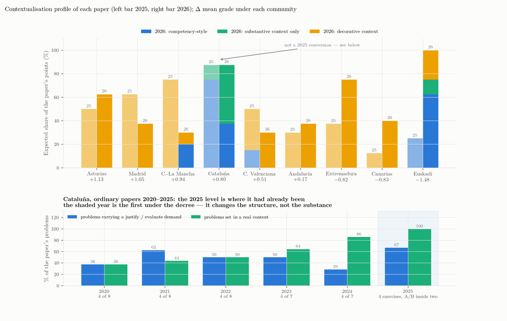

Figure 28: Contextualisation profile of each paper. For every community the left bar is 2025 and the right bar 2026; the stack splits the expected points into competency-style (blue), substantive context without an explain/evaluate demand (green) and decorative context (yellow). The change in the ordinary-sitting mean is printed under each community.

## 7.4 What the papers of the rising communities look like

**Asturias** ($+1.13$) and **Madrid** ($+1.05$), the two largest rises, had *no* competency-style exercise in either year. Asturias keeps its long-standing format — answer any five of eight two-point questions, so the whole paper is optional — and its contexts are decorative and, in 2026, whimsical: a melon weighed on Jupiter, two pumpkins and an apple, a kayak off Cudillero, a porcelain figurine in front of a mirror. Its 2025 paper actually demanded more reasoning (justify the sign of the work and whether it depends on the path; the Doppler echo question) than its 2026 paper, whose criteria-per-item score (0.25, tied with Canarias 2026) is among the lowest of the eighteen. Madrid’s obligatory question changed from a narrated dwarf-planet problem (Eris, 2025) to an item built around a measured potential between two plates (a $V(x)$ graph is printed, but $V(x)=-3x$ is also given in the text, so the graph is illustrative rather than read; a second coder scored it as no graph interpretation) — and the rest of the 2026 paper is bare: no context at all in five of seven items. Madrid’s optionality (75 %) did not move.

**Castilla-La Mancha** ($+0.94$) is the only rising community whose paper moved towards the competency model, and it did so modestly: a new obligatory two-point item set in the Artemis II re-entry (compare the orbital and escape speeds; compute the energy to dissipate for a safe landing) replaced a “choose two of three sections” Saturn problem, and the paper’s optionality fell from 100 % to 70 %. Its expected competency points went from 0 to 20 %, all of them guaranteed. Everything else in the 2026 UCLM paper is classical.

**Cataluña** ($+0.80$) was, in 2025, the most contextualised paper of the set — every exercise narrated (space debris and the end of the ISS, Millikan’s experiment, a coin inside a polycarbonate block in an art exhibition, a flute, a Na-24 blood-volume tracer) with “justifiqueu” sections throughout — and it stayed that way in 2026 (a Generalitat nanosatellite, Halley’s comet, an X-ray tube, a phone’s vibration motor, Chernobyl at forty years). Its structure did not change either: four exercises, options in two of them, 50 % optional. On this coding its competency share *fell* (75 → 38 %; 37.5 → 25 % for the stricter second coder), because two of the 2026 contexts drive calculations only and the explain/evaluate demands moved into the optional exercises; five of Cataluña’s six items carry a context in both years, and how many of those contexts count as *substantive* is the one place where the two coders differ materially (87.5 % against 25–37.5 %). Catalan students have sat contextualised papers for well over a decade — the UJI study rates Cataluña, with País Vasco, as the most competency-oriented system of 2015–2025 (Sánchez-Tarazaga & Gimeno Rovira, 2026) — so for them 2026 brought no change of genre.

**Comunitat Valenciana** ($+0.51$) went the other way. Its 2025 obligatory item was the most fully competency-style question in any 2025 paper outside Cataluña: a worker in a chlorine-electrolysis plant under an 18 kA cable, the Biot–Savart law to be stated and explained, the field to be drawn, and the result to be judged against the 2 T limit of Real Decreto 299/2016. In 2026 the obligatory item is a Deimos-2 satellite whose only demands are “deduce and calculate”. Valencia also redesigned its paper (six questions with 85 % optional points → four *apartados* with 80 %) and its 2026 paper is rich in *graph and figure interpretation* (57 % of items: a photographed rope wave, a laser scheme with angles to read, an $E_k$–$f$ photoelectric plot to interpret) — a different flavour of “competency” from the narrative one.

**Andalucía** ($+0.17$) kept its style — a conceptual true/false “razone” section plus a problem in each block — and *increased* optionality from 60 % to 75 % by making the conceptual sections optional too. No competency-style exercise in either year; decorative contexts only (a suitcase dragged through an airport, a child on a slide, a wind farm in the Strait of Gibraltar).

## 7.5 What the papers of the falling communities look like

**País Vasco** ($-1.48$). The 2025 paper had seven problems in four blocks, one obligatory (Galileo satellite — an ESA/AVS narrative in which the student is a member of a design team, with “justifica”, “explica” and “discute” sections and a figure to check results against), and the other three blocks chosen one of two among classical problems. The 2026 paper has six items, of which the two obligatory ones — an alarmist Starlink headline to be assessed (“¿te parece realista que este impacto destruya grandes zonas?”, plus a reasoning-without-calculation section) and a weather-station microgenerator with a specification to check (fem ≥ 0.50 mV) — meet all five EHU criteria save the graph, and all four options carry a context as well, two of them substantive (a violin and a concert, a projector to be chosen and justified, an oxidised photocathode, the C-14 dating of bone remains with a sketch of the decay law). Every measure moves at once: expected competency points 25 → 62.5 %, guaranteed competency points 2.5 → 5.0, criteria per item 0.86 → 2.67 (the highest of the eighteen papers, above Cataluña’s 2.33), optionality 75 → 50 %. The format changed as well: the 2026 items are cut into six to nine numbered sub-tasks scored in 0.25-point steps, with a constants table replacing per-problem data.

**Canarias** ($-0.83$) did not move towards the competency model at all — its 2026 paper has no substantive context (the one real setting, Cs-137 in dust after a *calima* episode, is decorative) — but it did change structure: from four blocks with a free choice of option A or B (100 % optional) to a paper with two obligatory items (3 points) and unequal block weights (2.5 / 3 / 3 / 1.5), 70 % optional. Three communities cut optionality by 25 points or more — Castilla-La Mancha and Canarias by 30, Euskadi by 25 — and two of the three fell. Castilla-La Mancha is the exception, and what it did with the space it recovered is the whole of the difference: one obligatory contextualised item, and nothing else changed.

**Extremadura** ($-0.82$) kept an identical structure (block A obligatory, choose one of two elsewhere, 75 % optional) and traded one decorative narrative (two Extremaduran students on an ESA mission, 2025) for another (the Artemis II launch, 2026), adding a photoelectric item built on an experimental data table. No competency-style exercise in either year.

## 7.6 Paper change against grade change

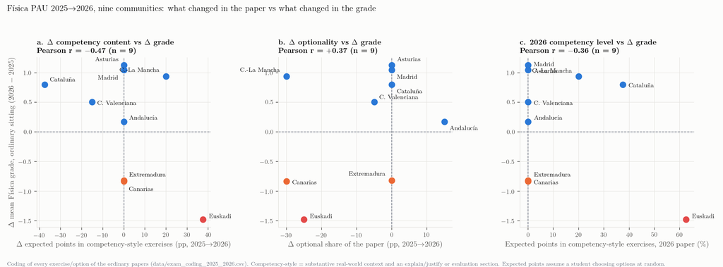

Figure 29: Change in the ordinary-sitting Física mean, 2025 → 2026, against (a) the change in expected competency points, (b) the change in the optional share of the paper and (c) the 2026 level of competency points. Nine communities; Pearson correlations printed in each panel. Orange = fell, red = Euskadi.

Table 44: Paper measures and grade change side by side, sorted by grade change. File: `data/exam_change_vs_grade.csv`.

| Community | Mean 2025 | Mean 2026 | Δ mean | Optional % 2025 | Optional % 2026 | Competency pts % 2025 | Competency pts % 2026 | Δ competency pts % | Oblig. competency pts 2025 | Oblig. competency pts 2026 | Criteria/item 2025 | Criteria/item 2026 |
| --- | --- | --- | --- | --- | --- | --- | --- | --- | --- | --- | --- | --- |
| Asturias | 5.49 | 6.62 | +1.13 | 100 | 100 | 0 | 0 | +0 | 0.0 | 0.0 | 0.75 | 0.25 |
| Madrid | 5.65 | 6.70 | +1.05 | 75 | 75 | 0 | 0 | +0 | 0.0 | 0.0 | 0.43 | 0.43 |
| Castilla-La Mancha | 5.86 | 6.80 | +0.94 | 100 | 70 | 0 | 20 | +20 | 0.0 | 2.0 | 1.25 | 0.67 |
| Cataluña | 6.04 | 6.84 | +0.80 | 50 | 50 | 75 | 38 | -38 | 5.0 | 0.0 | 2.00 | 2.33 |
| Comunitat Valenciana | 5.89 | 6.40 | +0.51 | 85 | 80 | 15 | 0 | -15 | 1.5 | 0.0 | 1.09 | 1.29 |
| Andalucía | 5.69 | 5.86 | +0.17 | 60 | 75 | 0 | 0 | +0 | 0.0 | 0.0 | 0.67 | 0.93 |
| Extremadura | 6.09 | 5.27 | -0.82 | 75 | 75 | 0 | 0 | +0 | 0.0 | 0.0 | 1.00 | 0.86 |
| Canarias | 5.08 | 4.25 | -0.83 | 100 | 70 | 0 | 0 | +0 | 0.0 | 0.0 | 0.38 | 0.25 |
| País Vasco | 5.47 | 3.99 | -1.48 | 75 | 50 | 25 | 62 | +38 | 2.5 | 5.0 | 0.86 | 2.67 |

With nine points most of these correlations are not significant, and the signs are what the question turns on. Across the six communities that rose, the expected competency content went **down or stayed at zero in five** (Asturias 0 → 0, Madrid 0 → 0, Andalucía 0 → 0, Valencia 15 → 0, Cataluña 75 → 38) and rose only in Castilla-La Mancha (0 → 20). The Basque increase ($+37.5$ points of expected share, $+2.5$ guaranteed points) is the largest in the set and is matched in direction by no rising community. The correlation between the change in competency content and the change in grade is negative ($r=-0.47$, $p=0.20$; $-0.62$, $p=0.08$ on the criteria-per-item measure; and $-0.85$, $p=0.004$ on the change in the share of contextualised points — the one correlation here that is significant, though it is also the least stable under a second coder, who gives $-0.59$). The correlation with the change in optionality is positive ($r=+0.37$): the two papers that removed the most choice (Castilla-La Mancha and Canarias, $-30$ points each; Euskadi $-25$) contain both the third-largest rise and two of the three falls, so optionality alone separates nothing.

What the coding therefore supports is narrower and, for the purpose of the 2027 discussion, more useful than a correlation:

### 7.6.1 The route, not the destination

The scatter panels above plot one year against one change, and a scatter cannot show a *route*. Two systems can arrive at similar competency content having come from opposite directions and from different distances, and after the Catalan archive that distinction is the question rather than a refinement of it. Figure Figure 30 therefore draws each community as an arrow from the competency-coded share of its 2025 paper to the share of its 2026 paper, against the change in its mean — one measure throughout, so the horizontal axis means the same thing for every arrow.

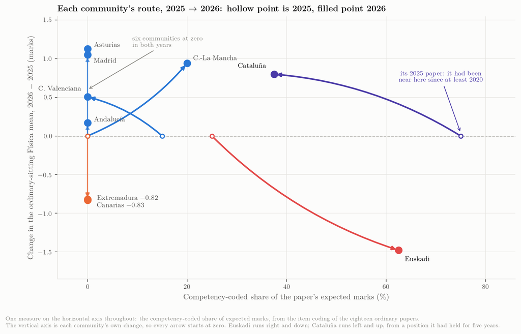

The cleanest statement is the one the earlier chapters left open: the reform framework (RD 534/2024) is common to all seventeen communities and cannot explain 2026; the *papers* are not common, and the Basque 2026 paper differs from its 2025 predecessor more than any other paper in this set differs from its own. Whether that difference produced the fall through the competency exercises, through the loss of choice, through the unfamiliar granular format, through the amount of reading the new items require in the time allowed (Andalucía, Extremadura and Madrid print 90 minutes on the paper; the EHU papers in this archive print no duration), or through marking-scheme effects that the corrector documents would show, is a question the grade data cannot settle and the exams alone cannot either. The natural next step is the one the UAM and Las Palmas commissions have taken elsewhere: an item-level analysis of the 2026 Basque scripts (marks by sub-task, by exercise and by option chosen), which would say directly whether the two obligatory competency exercises are where the 2 066 candidates lost their marks.

## 7.7 Did the nine sit comparable exams?

The previous section compares papers with each other. This one compares each paper with the structural criteria it was supposed to meet, because a comparison across communities is only a comparison if the nine were building to the same specification.

Three criteria are applied, in the form the EHU coordination applies them: optionality between 50 % and 85 % of the paper’s marks; at least 70 % of the marks from open or semi-constructed response; and at least one obligatory item carrying a substantive real-world context. A fourth measure is added and is not a criterion — the share of the paper’s expected marks that is competency-coded in the double-coded scheme of this chapter, meaning items that carry a substantive context *and* ask the candidate to explain or to evaluate.

Table 45: The nine 2026 papers against the structural criteria. File: `data/analysis/comparability.json`.

| Community | Optionality | C1 50–85 % | Open response | C2 ≥70 % | Obligatory contextualised items | C3 ≥1 | Competency marks | Change in the mean |
| --- | --- | --- | --- | --- | --- | --- | --- | --- |
| País Vasco | 50 % | yes | 100 % | yes | 2 (5.0 pt) | yes | 62.5 % | -1.48 |
| Castilla-La Mancha | 70 % | yes | 100 % | yes | 1 (2.0 pt) | yes | 20.0 % | +0.94 |
| Canarias | 70 % | yes | 100 % | yes | 1 (1.5 pt) | yes | 0.0 % | -0.83 |
| Extremadura | 75 % | yes | 100 % | yes | 1 (2.5 pt) | yes | 0.0 % | -0.82 |
| Asturias | 100 % | **no** | 100 % | yes | 0 (0.0 pt) | **no** | 0.0 % | +1.13 |
| Madrid | 75 % | yes | 100 % | yes | 1 (2.5 pt) | yes | 0.0 % | +1.05 |
| Andalucía | 75 % | yes | 100 % | yes | 1 (1.5 pt) | yes | 0.0 % | +0.17 |
| Comunitat Valenciana | 80 % | yes | 100 % | yes | 1 (2.0 pt) | yes | 0.0 % | +0.51 |
| Cataluña | 50 % | yes | 100 % | yes | 2 (5.0 pt) | yes | 37.5 % | +0.80 |

The 2026 papers against the three structural criteria. C2 is met by every paper — on a reading of the eighteen papers, none of the 146 coded items uses a closed response format — so it separates nobody. “Competency marks” is the share of expected marks from items that carry a substantive context *and* ask the candidate to explain or to evaluate; it is not a criterion, and it is where the nine differ most.

The second criterion separates nobody: on the reading made here, none of the 146 coded items in the eighteen papers uses a closed response format — no multiple choice, no true/false, no matching — so every paper meets it at 100 %. That is a judgement from reading the papers rather than a coded variable, since the coding scheme of this chapter records what an item *demands* and not how it is answered; it is recorded and set aside because it separates nobody either way.

The first and third do separate. **Asturias sits outside the optionality band at 100 %** — its candidates answer any five of eight questions and nothing on the paper is obligatory, so it fails the first criterion and the third at once. It is also the community with the largest rise in 2026 ($+1.13$). Every other 2026 paper sits inside the band, and every other 2026 paper carries at least one obligatory contextualised item, though in six of the eight that have one at all the item is contextualised without being competency-coded: a real-world framing around a calculation, with nothing asked that requires the candidate to explain or to judge.

Where the nine genuinely part company is the fourth column. Euskadi’s 2026 paper draws 62.5 % of its expected marks from competency-coded items; Cataluña 37.5 %, Castilla-La Mancha 20 %, and the remaining six exactly zero.

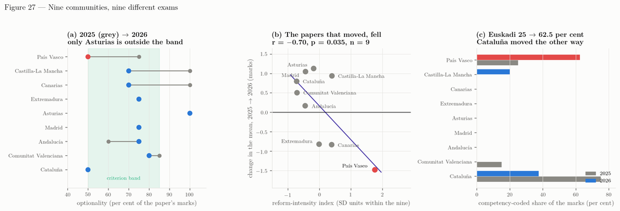

### 7.7.1 Cataluña: a steady state read as a conversion

Cataluña’s bar in Figure 28 is the one that misleads, and it misled this study first. Read across the row it looks like a community that converted in 2025 and pulled back in 2026. The ordinary papers say otherwise.

Table 46: Cataluña’s ordinary Physics papers, 2020–2025. File: `data/analysis/catalunya_history_2020_2025.csv`.

[output not shown]

Real settings and explicit demands to justify, reason or evaluate appear in every year from 2020, five before the decree: a singer’s voice and the Apollo 15 feather (2020), Tycho Brahe (2021), an eel’s locomotion and a launch (2022), the moons of Mars and the press coverage of a fusion announcement (2023), a planetary mission and the altitude of a firework (2024). What 2025 changed was the structure — four block exercises with an internal option — not the substance.

So Cataluña’s 75 % in 2025 is a steady state. It is a system that has examined this way for years, sitting about $+0.65$ above the field in both 2025 and 2026, once with three quarters of its marks competency-coded and once with half. That is the strongest evidence in this dossier against the proposition that competency examining depresses marks, and it moves the weight onto the transition rather than the paradigm.

The coding of 2020–2024 was done once, by one reader, after the 2026 result was known; 2025 and 2026 were coded blind by two ($\kappa = 0.76$). The series is evidence of a direction of travel, not a measurement of equal standing.

### 7.7.2 How far back the steady state goes, and what it cost

#### 7.7.2.1 The change is datable, and it is a step at 2020

One mechanical rule was applied to every Catalan paper from 2010: what share of its items require the candidate to justify, reason, explain, evaluate, interpret or say why, as against compute, state or describe. The rule is a verb list, it does not know which year it is reading, and it is reproducible (`scripts/35_demand_history.py`).

Table 47: The Catalan paper on one mechanical measure. 2024 falls back to 14.3 % on a paper whose structure changed to four-of-seven; 2025 returns to 66.7 %.

|  | mean | sd | range |
| --- | --- | --- | --- |
| 2010–2019 | **17.7 %** | 10.9 | 6.2 – 33.3 |
| 2020–2023 | **50.0 %** | — | 37.5 – 62.5 |

The level roughly triples and the step is at 2020 — five years before the decree and five years before the structural change that made the 2025 paper look converted. The series is noisy year to year, and no weight is put on any single year.

**The number that matters most here is the floor, not the step.** Cataluña’s lowest year across the whole traditional decade is **6.2 %**, and the mean is 17.7 %. It never set a paper that asked nobody to justify anything. Set against the Basque instrument of the same decade — forty per cent of the marks from a closed list of twenty-two recall titles, and competency-carried marks at zero as late as 2024 (Sixteen years of one paper) — the contrast is not one of degree. Cataluña intensified a practice it already had. Euskadi introduced one it did not have. The two measures are different and are not compared as numbers; the statement is qualitative and is meant as such.

#### 7.7.2.2 The cost is bounded, not measured

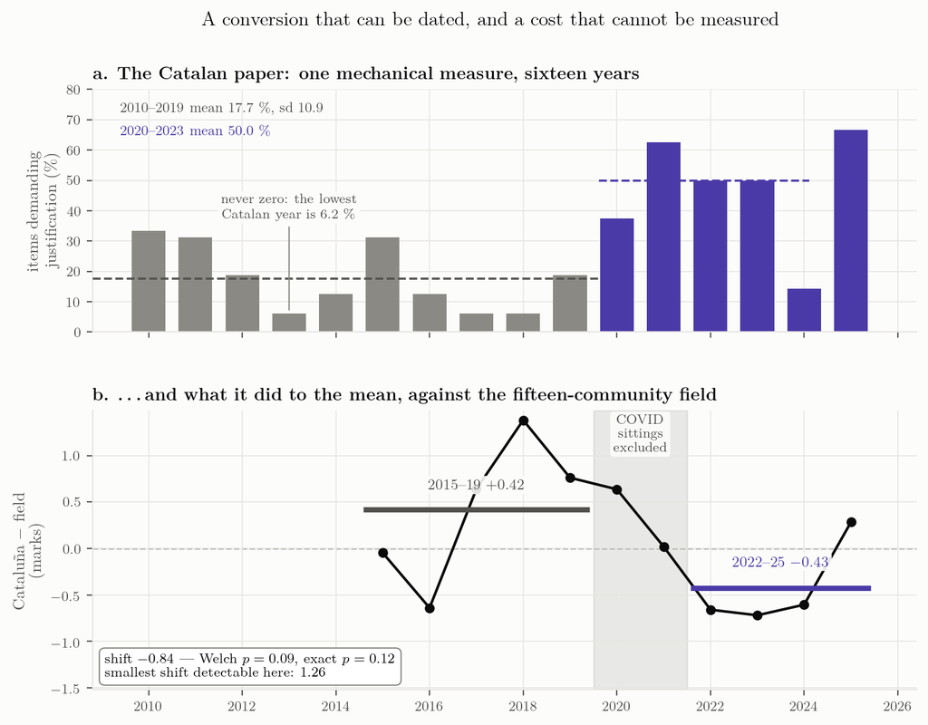

Figure 32: **a** — the Catalan paper on one mechanical measure, 2010–2025; grey before the 2020 step, violet after. **b** — Cataluña’s mean minus the fifteen-community field, with the COVID sittings excluded because they confound the treatment with the control. The power statement is printed on the panel so the $-0.85$ cannot be read without it.

Differencing against the fifteen communities with a complete 2015–2025 Ministry series, and dropping 2020 and 2021 — every community’s mean rose in those sittings, and they are also the first two years of the new Catalan style, so they confound what is being measured with what is controlling for it:

Table 48: The Catalan position against the field, before and after the 2020 step. File: `data/analysis/catalunya_event.json`.

|  | Cataluña $-$ field |
| --- | --- |
| 2015–2019 | $+0.42$ |
| 2022–2025 | $-0.43$ |
| **shift** | $\mathbf{-0.85}$ |

Welch $p = 0.087$; an exact permutation test over all 126 splits of the nine non-COVID years gives $p = 0.119$; dropping 2018, the pre-period’s outlier, gives $-0.60$ ($p = 0.19$); on medians it gives $-1.27$. **And the smallest shift this design can detect at 80 % power is 1.26 marks.** The estimate is smaller than the resolution of the instrument that produced it. It is a bound and not a coefficient, and it is reported that way here because the temptation to quote it as one is obvious.

Two further facts weaken it. **Most of the shift is the field rising, not Cataluña falling**: Cataluña’s own mean fell 0.34 while the field rose 0.50, so 59 % of the gap change belongs to the other communities. And Cataluña’s position against the field is restless in the absence of any change at all — the year-to-year standard deviation is 0.71, and in 2017 it moved $+1.28$ in a single year with nothing happening to its paper, which is half again the size of the entire post-conversion shift.

#### 7.7.2.3 What this licenses, and what it does not

It does not license a coefficient. “Cataluña shows that conversion costs 0.85 marks” would be quoting a figure the design cannot resolve, drawn mostly from other communities improving. No such sentence appears in this dossier.

It licenses two statements. First, a system that tripled its examined-reasoning share at a single step produced nothing a well-specified event study could detect across the six years that followed, while Euskadi’s second-year fall alone is $-1.65$ against the same kind of field — larger than the whole Catalan post-conversion displacement, and larger than the threshold that design would have needed to see one. The destination is not what hurt. That was already this dossier’s reading; it is the first evidence for it from outside the 2026 cross-section.

Second, and this is the one that carries: **Cataluña changed once, from a floor of 6.2 %, and then left the paper alone for five years** while its contextualisation drifted upward on its own. Euskadi went 0 to 25 to 62.5 per cent in two sittings and, in the same two sittings, halved optionality, reopened the syllabus and changed the marking regime. The Catalan archive cannot tell us what a conversion costs. It tells us what a conversion looks like when it is not also four other things at once.

#### 7.7.2.4 One measure that was built and discarded

The same mechanical rule was applied to the Basque archive, so that both systems would sit on one measure. It does not work, and the failure is recorded rather than hidden. The splitter returns 7 to 12 items for Basque years known to offer eight (`data/ehu_formats.csv`); some years yield only the theory titles; and one 2024 problem was counted twice because a degree symbol renders two ways in the text layer. An early version of the measure, before nouns were excluded from the verb list, put the 2024 Basque paper at 37.5 % against 12.5 % the year before — which, had it been believed, would have manufactured an instrument change in the one year this dossier says the instrument did not move, and handed the 2024 shape change a mechanism that does not exist. The Basque series was dropped; the script records why.

### 7.7.3 The field retreated in the second year

Across the other eight communities the competency-coded share of marks **fell** from 11.2 % to 7.2 % between 2025 and 2026. Cataluña halved its own while holding total substantive context at 87.5 %, keeping the context and dropping the demand; Comunitat Valenciana went to zero; five were at zero and stayed. The field against which the Basque-specific component is measured was moving away from the competency format while Euskadi moved towards it.

### 7.7.4 How far each paper moved

The criteria describe a level. What the 2026 results turn on is movement, so each paper’s change from its own 2025 predecessor is summarised in one index: the mean of four standardised movements — optionality (entering with its sign reversed, since cutting choice is the direction the orientations ask for), competency-coded marks, substantive context, and contextualised marks. Standardising inside the nine makes it a ranking device and not a scale with meaning of its own.

Table 49: Movement of each 2026 paper from its own 2025 paper, and the index built from it. File: `data/analysis/comparability.json`.

| Community | Optionality | Competency marks | Substantive context | Contextualised marks | Index | Rank | Change in the mean |
| --- | --- | --- | --- | --- | --- | --- | --- |
| País Vasco | -25 pp | +37.5 pp | +50.0 pp | +75.0 pp | +1.76 | 1 | -1.48 |
| Castilla-La Mancha | -30 pp | +20.0 pp | +20.0 pp | -45.0 pp | +0.39 | 2 | +0.94 |
| Canarias | -30 pp | +0.0 pp | +0.0 pp | +27.5 pp | +0.39 | 3 | -0.83 |
| Extremadura | +0 pp | +0.0 pp | +0.0 pp | +37.5 pp | -0.01 | 4 | -0.82 |
| Asturias | +0 pp | +0.0 pp | +0.0 pp | +12.5 pp | -0.19 | 5 | +1.13 |
| Madrid | +0 pp | +0.0 pp | +0.0 pp | -25.0 pp | -0.44 | 6 | +1.05 |
| Andalucía | +15 pp | +0.0 pp | +0.0 pp | +7.5 pp | -0.45 | 7 | +0.17 |
| Comunitat Valenciana | -5 pp | -15.0 pp | -15.0 pp | -20.0 pp | -0.71 | 8 | +0.51 |
| Cataluña | +0 pp | -37.5 pp | +0.0 pp | +0.0 pp | -0.72 | 9 | +0.80 |

Movement of each 2026 paper from its own 2025 paper, in percentage points of the paper’s marks, and the standardised index built from the four columns (optionality enters with its sign reversed). Across the nine communities the index correlates with the change in the mean at r = -0.701 (p = 0.0355); the fitted slope is -0.87 marks per index unit. Euskadi is the extreme point on both axes: dropping it leaves r = -0.396 (p = 0.332) among the other eight, so the coefficient is largely one community making the point. The rank correlation over all nine is rho = -0.383 (p = 0.308).

Euskadi ranks first on the index, at $+1.76$ standard deviations, more than a full standard deviation clear of the second. It is the only community that moved all four axes in the direction the orientations ask for: optionality down 25 points, competency-coded marks up 37.5, substantive context up 50, contextualised marks up 75. Castilla-La Mancha is the only other community that both cut optionality (by 30 points) and raised its competency share (0 → 20 %), and it moved contextualised marks 45 points the other way, which is why its index is $+0.39$ against Euskadi’s $+1.76$. Cataluña, the only community with a comparably competency-oriented paper, moved the competency share 37.5 points the *other* way. Three communities — Asturias, Madrid and Extremadura — moved on no axis except the contextualised share, and none of the nine is at zero on all four.

Across the nine the index and the change in the mean are related at $r = -0.70$ ($p = 0.035$) — the papers that moved, fell. That coefficient must be read with its leverage stated: Euskadi is the extreme point on both axes, and removing it leaves $r = -0.40$ ($p = 0.33$) among the other eight, while the rank correlation over all nine is $\rho = -0.38$ ($p = 0.31$). So this is not eight communities independently confirming a relationship. It is one community that moved furthest and fell furthest, in a field where the sign among the others is the same but the evidence is weak.

### 7.7.5 What this does and does not establish

It does establish that the nine 2026 Física papers are not nine measurements of one thing. They moved in different directions and by very different amounts, one of them sits outside the structural band on two criteria, and the community whose paper changed most is the community whose mean fell most.

It does not establish that anybody failed to comply with anything. The criteria used here are the ones that govern the Basque paper, taken from the orientation document the EHU coordination works to. The text of RD 534/2024 and the Ministry and CRUE orientations are not in this study’s source registry: they were not retrievable during the data hunt, and no attempt is made here to quote or paraphrase them. Whether those criteria bind every community, bind them in this form, or are advisory, is unresolved — and it is unresolved in a way that matters, because the difference between “Euskadi did what was required and others did not” and “Euskadi did more than was required” is the difference between a compliance question and a design choice. It is request 9 in Chapter 6.

## 7.8 A note on the UJI rating

The UJI study (Sánchez-Tarazaga & Gimeno Rovira, 2026) rated País Vasco and Cataluña as the most competency-oriented PAU systems of 2015–2025 and Madrid as the least. The present coding of the 2025 papers agrees on the ordering (Cataluña 2.00 and Euskadi 0.86 criteria per item versus Madrid 0.43), with the Basque 2025 paper owing its position to a single obligatory exercise. In 2026 the Basque paper (2.67) overtakes Cataluña (2.33); Madrid (0.43) does not move. If “competency orientation” is measured as the UJI study measures it, the 2026 Basque paper is now the most competency-oriented Física paper among the nine coded here on both coders’ readings (2.67 criteria per item against Cataluña’s 2.33; 2.50 against 1.83 for the second coder) — which is the strongest form of the hypothesis this chapter was asked to test, and the reason the item-level data matter.

# 8 Sixteen years of one paper

*The Basque Física exam 2010–2026: format, theory questions, the de facto syllabus and the marking rules — and what 2025 and 2026 changed*

## 8.1 Why the paper’s own history matters

Chapter 11 compared the 2025 and 2026 papers of nine communities and found that the Basque paper was the only one that changed genre between the two years. That comparison is horizontal. This chapter is vertical: it reads the Basque paper against *itself*, from 2010 to 2026, because the students who sat in June 2026 were prepared by teachers whose expectations were shaped by fifteen years of a very stable exam — and the account of that stability given by the coordinator, who has held the Física coordination since the 2018 edition (a two-option paper with two problems and two “theory questions”; theory drawn from a published list of titles; problems drawn, by long-standing convention, from a small subset of the syllabus; the modern-physics problem always photoelectric by a decision of the coordinators taken some twenty years ago and confirmed by the teachers’ meeting of 2024 for the 2025 paper, then lifted for 2026) can be checked against the papers.

All 34 papers (ordinary and extraordinary sittings, 2010–2026) and the guidance documents that EHU published for the 2025 model were downloaded from ehu.eus on 19 September (Data hunt; files in `sources/exams_ehu_hist/`, hashed in the source registry). Every problem and every theory question was inventoried by sub-topic (`data/ehu_problem_inventory_2010_2026.csv`, `data/ehu_theory_inventory.csv`; script `scripts/08_ehu_history.py`). The official list of theory titles, which EHU no longer publishes online, was supplied by the coordinator and is archived with the papers. Two things could *not* be verified from documents and are reported as the coordinator’s account: the minutes of the 2024 and 2025 coordination meetings (EHU does not publish them) and the origin of the photoelectric convention. The papers themselves settle the rest.

## 8.2 Four formats in sixteen years

Table 50: The four formats of the EHU Física paper, from the papers’ instruction blocks. File: `data/ehu_formats.csv`.

| Years | Format | Problems | Theory questions | Choice | Optional % |
| --- | --- | --- | --- | --- | --- |
| 2010–2019 | Two whole options (A/B) | 2 × 3 pts | 2 × 2 pts (closed list of titles) | choose one of two complete papers | 100 |
| 2020–2024 | Four-of-eight (COVID format, kept to 2024) | answer 2 of 4 (3 pts each) | answer 2 of 4 (2 pts each, closed list) | any 2 of 4 problems and any 2 of 4 questions | 100 |
| 2025 | LOMLOE year 1 | 4 × 2.5 pts; block A competencial and obligatory; B, C, D choose 1 of 2 | none (theory only through explanations inside problems) | 1 of 2 in three blocks | 75 |
| 2026 | LOMLOE year 2 | 4 × 2.5 pts; 1 and 2 competencial and obligatory; 3 and 4 choose a/b | none | 1 of 2 in two blocks | 50 |

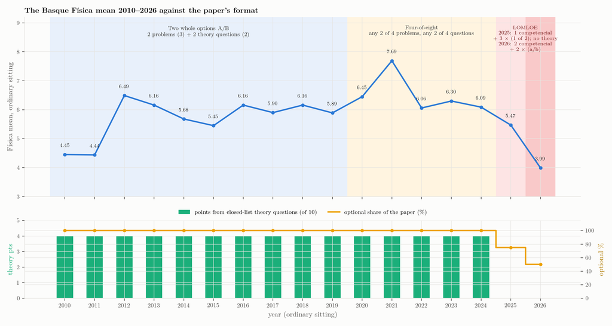

Figure 33: The ordinary-sitting Física mean 2010–2026 with the paper’s format shaded; below, the points awarded through closed-list theory questions and the optional share of the paper.

The 2025 paper broke with both: seven problems in four blocks of 2.5 points, no theory questions at all, one block (A, gravitation) obligatory and written as a contextualised “competencial” exercise, the other three blocks with a choice of one problem out of two. The 2026 paper went one step further: six items, blocks A and B (gravitation, electromagnetism) both obligatory and competencial, blocks C and D with options a/b, a constants table on the paper, and most exercises split into six to nine numbered sub-tasks (option C1 has three lettered parts and none) carrying explicit 0.25-point marks.

## 8.3 Forty per cent of the marks from a list of titles

Table 51: The 22 titles of the official list *Evaluación para el Acceso a la Universidad: Cuestiones teóricas* (UPV/EHU and Departamento de Educación, bilingual, each title followed by a development guide for students and correctors; `sources/exams_ehu_hist/ehu_theory_list_official.pdf`), with the number of times each was set as a “cuestión” in 2010–2024 (120 questions in 30 papers). File: `data/ehu_theory_inventory.csv`.

| No. | Title in the official list (Spanish version, abridged) | Times set 2012–2024 | Times set 2010–2024 |
| --- | --- | --- | --- |
| 1 | Movimiento armónico simple. Ejemplos. Ecuación. Definición de las magnitudes. Ecuaciones de la velocidad y de la aceleración. | 7 | 7 |
| 2 | Movimiento ondulatorio en una dimensión. Ecuación. Definición de las magnitudes. Velocidad de propagación. Distinción entre ondas transversales y longitudinales. | 4 | 5 |
| 3 | Reflexión y refracción de ondas: concepto, índice de refracción, leyes… Conceptos de ángulo límite y reflexión total. | 5 | 5 |
| 4 | Ondas estacionarias. Definición y ejemplos. | 3 | 3 |
| 5 | Lupa. Descripción. Esquema de la formación de imágenes. Aumento. | 5 | 6 |
| 6 | Cámara fotográfica. Descripción. Esquema de la formación de imágenes. | 2 | 2 |
| 7 | El ojo humano. Descripción. Esquema de la formación de imágenes. | 4 | 4 |
| 8 | Defectos de la visión. Hipermetropía y miopía. | 4 | 4 |
| 9 | Ley de Gravitación Universal de Newton. Intensidad de campo. Campo creado por una masa puntual (o esférica). Ejemplo: el campo gravitatorio terrestre. | 4 | 4 |
| 10 | Campos de fuerza conservativos y no conservativos. Energía potencial gravitatoria. Potencial gravitatorio. Energía mecánica total. Principio de conservación de la energía. | 4 | 5 |
| 11 | Leyes de Kepler. Enunciados. Deducción de la 3ª Ley para órbitas circulares a partir de la Ley de Gravitación. | 9 | 10 |
| 12 | Líneas de fuerza y superficies equipotenciales en el campo gravitatorio creado por una masa puntual (o esférica). | 4 | 4 |
| 13 | Ley de Coulomb. Intensidad de campo eléctrico. Campo electrostático creado por una carga puntual positiva y negativa; líneas de fuerza. | 5 | 8 |
| 14 | Fuerza ejercida dentro de un campo magnético uniforme: a) sobre una carga puntual en movimiento; b) sobre un conductor lineal de corriente. | 4 | 5 |
| 15 | Fuerzas entre corrientes eléctricas. Dos hilos rectos, paralelos e infinitos. Definición de amperio. | 4 | 5 |
| 16 | Campos magnéticos producidos por corrientes. Ley de Biot-Savart: a) corriente recta e infinita; b) corriente circular (espira). | 1 | 2 |
| 17 | Ley de Faraday y Lenz para la inducción electromagnética. Valor de la fuerza electromotriz inducida. Sentido de la corriente. | 6 | 8 |
| 18 | Generador de corrientes alternas sinusoidales (alternador). | 3 | 3 |
| 19 | Efecto fotoeléctrico. Descripción. Explicación cuántica. Teoría de Einstein. Frecuencia umbral. Trabajo de extracción. | 8 | 9 |
| 20 | Radiactividad natural. Desintegración radiactiva. Emisión de partículas alfa, beta y gamma. Leyes de Soddy y Fajans. | 10 | 12 |
| 21 | Fisión nuclear. Descripción y ejemplos. Bombas y centrales nucleares. Pérdida de masa. Ecuación de Einstein. | 5 | 6 |
| 22 | Fusión nuclear. Descripción y ejemplos. Bombas y posibles centrales nucleares. Pérdida de masa. Ecuación de Einstein. | 3 | 3 |

Until 2024, four of the ten points were awarded for two theory questions, and from 2012 the questions were not questions in the usual sense: they reproduced, verbatim, the title of an entry in a syllabus list. (The sixteen questions of 2010 and 2011 are the exception: they are free-form, and three of them do not correspond to a single title at all. From 2012 onwards all 104 are verbatim.) The titles set are of the kind: “Lupa. Descripción. Esquema de la formación de imágenes. Aumento.” (July 2022), “Defectos de la visión. Hipermetropía y miopía.” (June 2019), “Reflexión y refracción de ondas: concepto, índice de refracción, leyes… Conceptos de ángulo límite y reflexión total.” (June 2024). The list was an official document: a bilingual sheet issued jointly by the university and the Basque Department of Education, *Cuestiones teóricas*, which states that the questions “aparecerán (tal y como están escritas) en la Evaluación para el Acceso a la Universidad”, gives for each title a guide to the content a student should include, and was sent to the correctors as their marking reference. It has 22 titles, and the inventory reconstructed from the papers before the document was in hand recovers exactly those 22: every title was set at least once between 2010 and 2024 (the photographic camera twice, the Biot–Savart title twice; radioactivity twelve times, Kepler ten, the photoelectric effect nine); five titles — radioactivity, Kepler’s laws, the photoelectric effect, Faraday–Lenz and Coulomb’s law — account for 47 of the 120 questions. The document is no longer online, but any teacher who kept it, or the papers, had the whole of the theory component in advance, together with the marking guide. Under the A/B format a student who could reproduce two entries from that list held 4 points before touching a problem; under the four-of-eight format, with four titles on the paper and two to be chosen, the same 4 points were even more accessible. In 2025 this component disappeared in a single step. The other communities’ 2025–2026 papers offer no exact analogue: Andalucía keeps a large share of short “razone” conceptual items (about 5–6 of 10 expected points), Valencia had 1.5-point “cuestiones” in 2025 and dropped them in 2026, Castilla-La Mancha’s 2026 paper has two fixed 0.5-point items, and Asturias, Madrid, Cataluña, Extremadura and Canarias set none in either year — so removing theory is not, by itself, what separates Euskadi from the communities that rose; what is specific to Euskadi is going from 4 points of closed-list theory to none in one year.

## 8.4 The de facto syllabus: which problems were actually set

Table 52: Problems set per sub-topic and period, all options counted (146 problems in 34 papers). File: `data/ehu_problem_inventory_2010_2026.csv`.

| Block | Problem sub-topic | 2010–19 (20 papers) | 2020–24 (10 papers) | 2025 (2) | 2026 (2) |
| --- | --- | --- | --- | --- | --- |
| Gravitación | Circular orbit / satellite (v, T, energies, escape from orbit) | 12 | 6 | 2 | 1 |
| Gravitación | g on a planet’s surface or at height (mass, radius, g(r)) | 5 | 2 | 0 | 0 |
| Gravitación | Elliptical orbits, Kepler, angular momentum | 1 | 0 | 0 | 1 |
| Gravitación | Launch from the surface, maximum height, escape | 2 | 1 | 0 | 0 |
| Electromagnetismo | Point charges: field, potential, work | 6 | 4 | 2 | 0 |
| Electromagnetismo | Charged particle in a uniform E field (plates, accelerator) | 4 | 0 | 0 | 0 |
| Electromagnetismo | Charged particle in a uniform B field (circular motion) | 6 | 2 | 0 | 0 |
| Electromagnetismo | Field of straight currents, forces between wires | 4 | 1 | 1 | 0 |
| Electromagnetismo | Induction: loop or rod, emf, generator | 3 | 2 | 1 | 1 |
| Electromagnetismo | Velocity selector / mass spectrometer | 0 | 0 | 0 | 1 |
| Ondas | Travelling harmonic wave (equation, v, phase) | 11 | 6 | 1 | 0 |
| Ondas | Simple harmonic motion (spring–mass, energy) | 5 | 2 | 1 | 1 |
| Ondas | Standing waves (string, pipe) | 0 | 0 | 0 | 1 |
| Ondas | Sound intensity, decibels | 0 | 0 | 0 | 0 |
| Óptica | Refraction, Snell, total internal reflection | 4 | 6 | 1 | 0 |
| Óptica | Thin lenses (magnifier, projector, camera) | 6 | 4 | 0 | 2 |
| Óptica | Spherical mirrors | 0 | 0 | 1 | 0 |
| Moderna | Photoelectric effect / photon energy | 11 | 3 | 4 | 2 |
| Moderna | Radioactive decay, half-life, dating | 0 | 0 | 0 | 2 |
| Moderna | Nuclear mass–energy, binding energy, reactions | 0 | 0 | 0 | 0 |
| Moderna | Special relativity | 0 | 0 | 0 | 0 |
| Moderna | de Broglie wavelength | 0 | 1 | 0 | 0 |

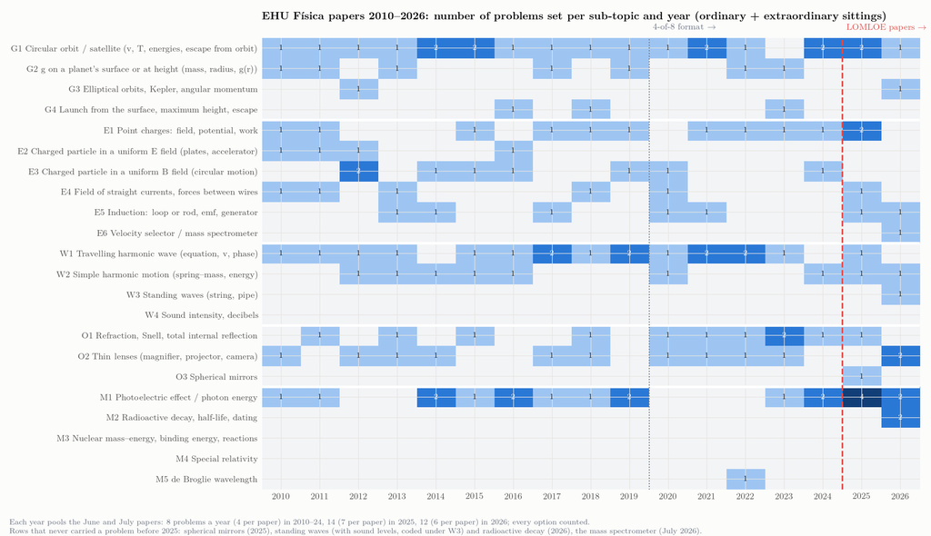

Figure 34: Number of problems per sub-topic and year, June and July papers pooled. Sub-topics whose row is empty until 2025 had never been the subject of a problem: spherical mirrors (June 2025), standing waves with sound levels and radioactive decay (June 2026), the mass spectrometer (July 2026). Nuclear mass–energy, special relativity and sound intensity never were.

The inventory confirms the coordinator’s description of a syllabus that had narrowed in practice to a small set of problem types:

- **Gravitation** was a circular-orbit problem 18 times out of 29 (2010–2024), a surface-gravity problem 7 times, a launch problem 3 times and a Kepler/elliptical problem once (July 2012). Angular momentum never appeared in a problem.
- **Electromagnetism** rotated among point charges (10), a charged particle in a magnetic field (8), induction (5), straight currents (5) and a particle in a uniform electric field (4, none after 2016). The velocity selector and the mass spectrometer never appeared until July 2026, where the mass spectrometer is the *obligatory* problem 2.
- **Waves** meant a travelling harmonic wave (17) or a spring–mass oscillator (7). **Standing waves** were a theory title (set three times) but never a problem until the violin string of June 2026, which also asks for sound levels in decibels — a quantity that had never been examined in any form. The Doppler effect never appeared.
- **Optics** meant refraction (10) or thin lenses (10). **Spherical mirrors** had never been set — until the concave mirror of June 2025 (C1, as an alternative to a classical wave problem).
- **Modern physics** is the clearest case: 14 of the 15 modern-physics problems of 2010–2024 are photoelectric or photon-energy problems, the one exception a de Broglie calculation in July 2022. Radioactivity, fission and fusion existed only as theory titles. The 2025 papers kept the convention absolutely (all four block-D problems, June and July, are photoelectric), exactly as the coordinator reports the 2024 teachers’ meeting had insisted; the 2026 papers lift it: C-14 dating (June 4b) and Pu-239 decay (July 4b) appear beside a photoelectric option.

## 8.5 What the predictability built — and what two courses of notice could not undo

The two preceding sections describe an instrument. Put together, they describe an incentive, and the incentive is what a school responds to.

A teacher optimising for their students’ results under that instrument would teach the twenty-two titles thoroughly, drill the problem templates that recur, and let the rest go. That is not neglect; it is the correct response to the incentive, and any system that holds teachers accountable for results produces it. **The exam was the curriculum**, and the *de facto* narrowing of the previous section is what the exam wrote.

The clearest case is modern physics. Fourteen of the fifteen modern-physics problems set between 2010 and 2024 were photoelectric. Fission and fusion existed **only as theory titles** — examinable as recited prose, never as a calculation. In 2026 carbon-14 dating and plutonium-239 decay appear as problems. A student who had learned nuclear physics exactly as the exam had asked for it, for fifteen years, met it as arithmetic.

### 8.5.1 The schools were told, and told in time

This must be stated plainly, because the obvious inference from the paragraphs above is the wrong one. The reopening was **announced in 2024**, and the two academic years **2024–25 and 2025–26 were designated transitional** by the coordination precisely so that schools could prepare for a complete syllabus in 2026. The schools knew. They were given two courses.

So the gap is not an information failure, and nothing in this dossier should be read as one. What took longer than two years was not the knowledge but the **practice**. Announcing that a topic is examinable does not by itself create worked-example banks, mock papers, a sequence for the year that leaves room for it, or the teacher’s own fluency in setting and marking that kind of question. Fifteen years of materials and habits were tuned to an instrument that no longer exists, and two cohorts is not long enough to retune them.

That distinction — informed in time, and still not practised — is the honest form of the inertia argument, and it is the form that survives contact with the record.

### 8.5.2 And yet in June 2026 the old route was still open

There is a further fact about the 2026 papers that cuts against the obvious form of this argument, and it has to be stated before the argument is used.

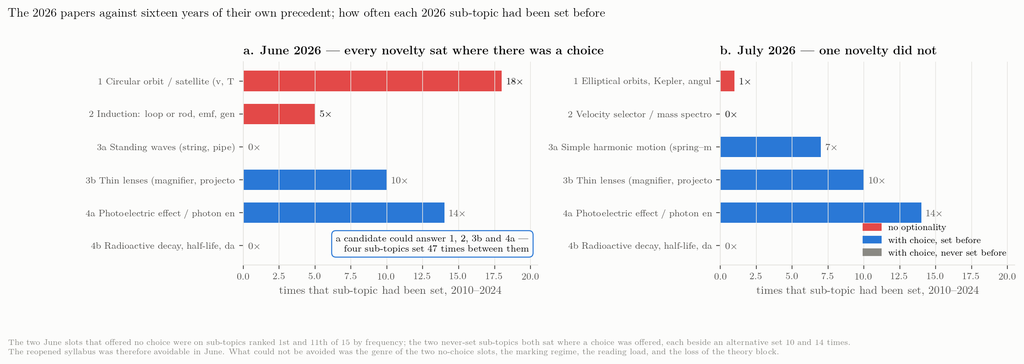

Figure 35: The 2026 papers against sixteen years of their own precedent. In June the two slots that offered **no optionality** were set on sub-topics ranked 1st and 11th of 15 by frequency, and the two sub-topics never set before — standing waves and radioactive decay — both sat **where a choice was offered**, each beside an alternative that had been set 10 and 14 times. July is the counter-case: its second slot offered no choice and was a mass spectrometer, never set before.

The June 2026 sitting — the one that produced 3.99 — contained no unavoidable novelty at all:

Table 53: June 2026 slot by slot, against its own precedent.

| slot |  | sub-topic | set 2010–2024 |
| --- | --- | --- | --- |
| 1 | **no optionality** | circular orbit / satellite | **18×** |
| 2 | **no optionality** | induction | 5× |
| 3a | choice | standing waves | **0×** |
| 3b | choice | thin lenses | 10× |
| 4a | choice | photoelectric effect | 14× |
| 4b | choice | radioactive decay, dating | **0×** |

A candidate could answer **1, 2, 3b and 4a** — four sub-topics set **47 times** between them in the preceding fifteen years, including the single most frequent sub-topic in the entire archive in the opening slot, where no choice was offered. Both novelties sat in slots that offered a choice, with heavily drilled alternatives beside them. **The reopened syllabus was, in June, entirely avoidable.**

And the mean still fell 1.48.

That has a consequence which must be carried through the rest of this dossier. **Meeting unfamiliar content cannot be what happened in June 2026**, because a student prepared exactly as fifteen years of this exam had taught them to prepare could have sat the whole paper on familiar ground. The content channel of the syllabus hypothesis is therefore not merely bounded; for the ordinary sitting it is close to empty.

What could *not* be avoided is a short list: the **genre** of the two slots with no optionality, both competencial; the marking regime in its second year; the reading load; and the disappearance of the theory block, four points of the ten that had been guaranteed by preparation.

So the inertia does not disappear — **it relocates**, and into two channels that are sharper than “they met what they had not seen”.

The first is **preparation spread thinner**. Schools had to cover the whole syllabus precisely *because* they could not know what would be set. A teaching year is finite. Covering block E in full, and the un-set corners of blocks C and D, is time taken from consolidating orbits, induction, lenses and the photoelectric effect. The student who took the old route in June 2026 was therefore less drilled on that route than a 2024 student had been — not because the route changed, but because the year had to cover more ground to reach it.

The second is **familiar physics in an unfamiliar form**. Slot 1 was a circular-orbit problem, the most-set sub-topic in the archive, presented as a Starlink headline to be read, judged and explained — and with no alternative to turn to. Fifteen years had trained the recognition of a problem type, not the reading of a real-world scenario built on one. On this reading the inertia bites hardest exactly where the content did not change at all.

### 8.5.3 What would now separate them

These two relocations make a prediction the content version did not, and it is testable within the June paper itself. Slot 4 offered the photoelectric effect (set 14 times) against carbon-14 dating (never set). Two quantities settle it:

1. **How many candidates took each option.** If they overwhelmingly took 4a, the novelty was avoided in fact and not merely in principle.
2. **How they scored on 4a.** If candidates did worse on the most standardised item in the archive than their 2024 and 2025 counterparts did, content novelty is excluded by the paper’s own internal evidence, and preparation, genre and marking must carry the fall between them.

That is the smallest measurement identified anywhere in this dossier and it bears on the largest question: one option take-up and the sub-item marks of one problem, in three years.

### 8.5.4 Why this is the mechanism Cataluña lacks

Chapter 11 shows that Cataluña has set papers with real settings and explicit justification demands in every year since 2020, on an all-problems format with optionality around half and no closed theory list at all. There was therefore no accumulated equilibrium to unlearn. When the decree arrived, Catalan teaching had nothing to undo; Basque teaching had fifteen years of it, and two courses in which to undo it.

Notice what that comparison does *not* say. It does not say the Basque schools were worse prepared in any sense they could have controlled. It says the two systems entered the same reform carrying different amounts of accumulated practice, and that the quantity which mattered was not notice but practice.

### 8.5.5 What would test it

Inertia of this kind leaves the same trace in a mean as paper difficulty, marking severity and reading load, so it is unidentified on published aggregates exactly as the budget says. But unlike the others it makes a prediction about *where* in the paper the marks went: **the loss should be concentrated in the sub-tasks that examine what had never been set as a problem** — modern physics beyond the photoelectric effect, standing waves, mirrors, decibels. Marks at sub-task level would test that directly, and it is a sharper test than the general one, because the competing hypotheses do not predict a topic pattern.

## 8.6 The marking rules, year by year and community by community

Table 54: Marking rules as printed in the corrector documents (EHU 2012–2024 papers with embedded criteria; EHU 2025 model of 18 November 2024; EHU 2026 solucionarios; the other communities’ 2025 and 2026 corrector documents in `sources/exams/`). File: `data/marking_rules_2025_2026.csv`.

| Corrector document | Symbolic-first rule | Units and error rules | Language rules | Granularity | Constants table |
| --- | --- | --- | --- | --- | --- |
| País Vasco 2012–2024 | no | qualitative: ‘se penalizará’ missing units, purely mathematical developments, incoherent results; no amounts | no | no | no |
| País Vasco 2025 | no | units mandatory in the final answer; significant figures and exponent notation ‘penalised’ (no amount); conceptual errors weigh more than calculation errors | −0.1 from the 3rd error, cap 1 pt; syntax/coherence up to −0.5, total cap 1 pt | no | no |
| País Vasco 2026 | yes | −0.1 units; −0.1 repeated vector-symbol errors; −0.1 rounding/significant figures; grave errors (wrong equations, scalar/vector confusion) can void the section | as 2025 | 0.25-pt sub-items (a.1, a.2 …) | yes (constants table on the paper) |
| Canarias 2025 | no | −0.1 units, vector symbol, prefixes, light calculation errors, rounding; capped at 20 % of the section; grave errors void it | −0.1 per spelling error | sections of 1–1.5 pts | no |
| Canarias 2026 | no | full CRUE list: −0.1 units, vector symbol, prefixes, factor of 10, transcription, rounding; no cap; grave errors void the section | −0.1 per spelling error, repeats not counted | sections of 1–1.5 pts | no |
| Comunitat Valenciana 2025 and 2026 | yes (‘realiza primero el cálculo simbólico’) | 60 % symbolic set-up and explanation / 40 % numerical result; units and significant figures worth +0.1 | linguistic criteria applied (general PAU rule) | 0.1-pt detail in the criteria | no |
| Cataluña 2025 and 2026 | no | −0.25 per problem for unit errors; item-specific deductions (−0.1, −0.25) in the pauta | linguistic correction stated | 0.25-pt detail | no |
| Madrid 2025 and 2026 | no | ‘destreza en la obtención de resultados numéricos y el uso correcto de las unidades’; marks in multiples of 0.25 (2025) / 0.1 (2026) | coherence, cohesion, spelling ‘se evaluará’ | 0.25 / 0.1 | no |
| Asturias 2025 (2026 criteria are worked solutions only) | no | −0.25 per section for a missing/incorrect unit of a calculated magnitude | general PAU rule | — | yes (constants table on the paper) |
| Andalucía 2025 and 2026 | no | −0.1 each for a missing or wrong unit (cap −0.25 per apartado b), for vector/scalar character and for rounding | 2026: −0.1 from the 3rd spelling error (Junta general rule) | 0.25 / 0.5 sub-sections | no |
| Extremadura 2025 and 2026 | no | 2025: unit errors up to −1 pt in the exam; 2026: −50 % of the section for a unit error, cap 1 pt | −0.1 from the 3rd error, cap 1 pt; syntax/vocabulary up to −0.5 (same wording as EHU 2025) | 0.1–0.3 detail | no |
| Castilla-La Mancha 2026 | no | not read (paper only) | −0.25 per 3 faults, cap 1 pt (on the paper) | — | no |

From 2012 to 2024 the EHU criteria, printed after each paper, were two qualitative paragraphs: a *cuestión* is worth up to 2 points for a precise definition with rigour; a *problema* up to 3, later sections independent of earlier ones; planteamiento, laws, diagrams and units are valued; “purely mathematical developments without physical justification”, missing units and incoherent results “se penalizarán” — with no amounts. The 2025 model (18 November 2024) introduced, for the first time, numerical penalties: −0.1 per spelling error from the third, up to 1 point per exam; up to −0.5 for syntax, coherence and presentation; units mandatory in the final answer; significant figures and exponent notation “penalised”; conceptual errors weighing more than arithmetic ones; a correct result counting only if justified. The 2026 solucionarios add the rest of the list the coordinator describes: symbolic solution before numerical substitution; −0.1 for missing or wrong units, for repeated vector-symbol errors, for rounding and significant figures; grave errors (wrong equations, scalar/vector confusion) voiding the whole section; sub-tasks marked at 0.25-point resolution against a printed table.

## 8.7 What choice alone is worth

Optionality has been a recurring suspect since Chapter 6, so it is worth putting a number on it. A student who chooses among items scores, on average, more than the same student answering fixed items, because the choice picks up item-to-item luck. A simple simulation makes the size of this *selection premium* explicit for each EHU format: 200 000 simulated students with ability $a \sim \mathcal N(0.55,\,0.20)$ clipped to $[0,1]$; each item scored as $p_i \cdot \operatorname{clip}(a+\varepsilon_i,0,1)$ with $\varepsilon_i \sim \mathcal N(0,\sigma)$; the student answers the best items each rule allows. Holding the population and the items fixed and changing only the rule:

Table 55: Expected gain, in points out of 10, over a paper with no choice, for three values of the item-to-item noise $\sigma$. File: `data/ehu_selection_premium.csv`.

| Format (selection rule) | Premium, item SD 0.10 | Premium, item SD 0.20 | Premium, item SD 0.30 |
| --- | --- | --- | --- |
| no choice (4 × 2.5) | +0.00 | +0.00 | +0.00 |
| 2026: 2 obligatory + 2 × best of 2 | +0.28 | +0.53 | +0.73 |
| 2025: 1 obligatory + 3 × best of 2 | +0.41 | +0.79 | +1.09 |
| 2010–19: better of two options | +0.28 | +0.54 | +0.74 |
| 2020–24: best 2 of 4 + best 2 of 4 | +0.65 | +1.24 | +1.72 |

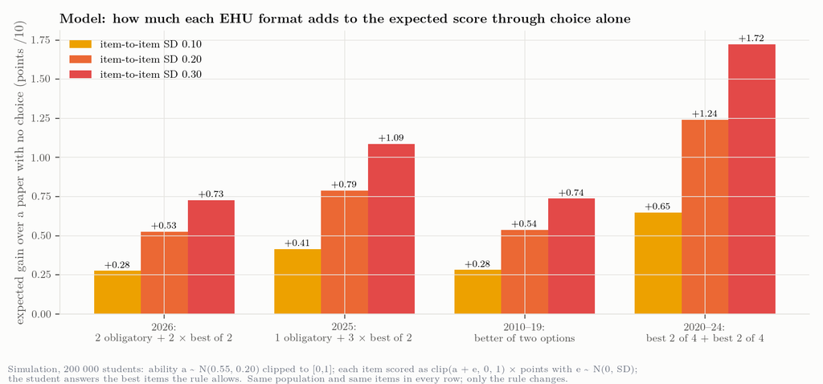

Figure 36: Selection premium of each EHU format under the same population and items.

Three readings. The four-of-eight format of 2020–2024 was by a wide margin the most generous ever used (+1.2 points at $\sigma = 0.2$), which is consistent with those years carrying the highest means of the series without any change in the population. The 2025 format still gave more through choice (+0.8) than the classical A/B paper (+0.5), and the 2026 format (+0.5) is, in terms of choice, a return to the 2010–2019 level — years in which the mean ran from 4.44 to 6.49. And the step from 2025 to 2026 removes about a quarter of a point through choice, a fifth of the observed $-1.48$. Optionality is real, measurable and worth restoring where it is cheap, but it cannot carry the 2026 result; the earlier chapters’ suspicion is confirmed and bounded at the same time.

## 8.8 Reading 2025 and 2026 together

The most useful thing the sixteen-year record does is to separate what changed in 2025 from what changed in 2026, because the grade series reacts very differently to the two steps.

**2025** was the larger structural break: the theory questions (4 points from a closed list) vanished; the A/B and four-of-eight choice gave way to one obligatory competencial block and three binary choices; the problem count and weights changed; numerical language penalties and a justification-first rule appeared. The 2025 Basque mean fell by $0.62$ — *less* than the national average fall of $0.81$ in the first LOMLOE year, when fourteen of seventeen communities fell (Chapter 3). Whatever the 2025 changes cost, the Basque cohort absorbed them at least as well as the Spanish average did.

**2026** changed less on paper and more in kind. Every feature of the 2026 step is an intensification of something already present in 2025, plus two novelties: the competencial genre went from a quarter of the marks to half and from one obligatory exercise to two; choice fell from three binary options to two; the marking moved from qualitative rules with two numerical penalties to a printed −0.1 list, symbolic-first, and 0.25-point sub-tasks; and the de facto syllabus was opened — modern physics to any topic, blocks C and D to standing waves, decibels and mirrors. None of these alone is large by the yardsticks this study can apply (the choice premium is a quarter of a point; the new topics are avoidable; the marking rules are shared with communities that rose). What is not shared with any community that rose is the *joint* movement of content type, exposure, format and marking in a single year, on top of a 2025 break that the schools had had one cycle to adapt to — and the coordinator’s account adds the missing mechanism: a school system trained for fifteen years on a paper whose theory came from a list and whose problems came from a dozen templates had, for 2026, to teach the whole of block E and the un-set corners of blocks C and D, while its students met an exam whose obligatory half asked them to read, judge and explain rather than to recognise.

That reading is consistent with everything the earlier chapters found — the cohort-wide displacement rather than a subgroup effect (Chapter 4), the concentration of the damage in Física and Matemáticas II (Chapter 5), the Canarian twin with the same penalty list and a structural cut of choice (Chapter 3) — and it is still not a causal estimate. It is, however, a precise statement of what an item-level analysis of the 2026 scripts should be able to confirm or refute: whether the marks were lost (i) in the two obligatory competencial exercises rather than in the options, (ii) in the explain/evaluate sub-tasks rather than in the calculations, (iii) through accumulated −0.1 penalties and voided sections, or (iv) in the newly-examined topics for those who chose them. Each of those has a different remedy for 2027, and only the first two would justify touching the competency design itself.

## 8.9 For the record: what is documented and what is testimony

Documented on ehu.eus and archived here: the 34 papers; the criteria embedded in the 2012–2024 papers; the 2025 model paper of 18 November 2024 with its general criteria (and its earlier October version, which proposed four obligatory competencial exercises with a rubric and was withdrawn); the 2025 and 2026 solucionarios with the 2026 corrector rules. Documented by the coordinator’s own file and archived here: the official EHU–Department list of 22 theory titles with its development guide. Testimony of the coordinator, consistent with the papers but not independently documented: the decision of the coordinators’ meeting some twenty years ago restricting modern-physics problems to the photoelectric effect (borne out by 14 of 15 problems 2010–2024 and all four of 2025), the 2024 teachers’ meeting confirming that restriction for 2025 against the coordinator’s position, and the 2025 decision to open block E for 2026 (borne out by the 2026 papers). No coordination-meeting minutes are published; if the Department or the university asks for the record, these two decisions are the ones to document.

# 9 The paradigm change, seen whole

*Every design decision behind the 2026 paper, what it was for, what it cost, and what the data now say — followed by the order in which we came to see it*

## 9.1 Why this chapter exists, and how to read it

Everything else in this dossier works from the outside in: a mean fell, and the question is what moved it. This chapter works from the inside out. It sets out the paper as a made thing — a set of decisions taken by people for reasons, under constraints they did not choose — and asks of each decision what it was for, what it cost, and what the measurements say.

It exists because the design side of the story arrived in pieces, in the order that questions happened to be asked, and that is the worst possible order to read it in. A reader meeting the itemisation for the first time in the middle of a marking simulation cannot see that the same decision also explains the reading load. The order of discovery is preserved, because it is part of the evidence and because it shows which conclusions were reached under pressure, but it is put second, in part two.

Two warnings. The account of *intent* in part one comes from the coordination and is **testimony**; it is labelled as such where it carries weight, and the dossier does not treat an explanation of why a decision was taken as evidence that it was taken for that reason alone. The account of *effect* is measurement, and is sourced. Where the two disagree, both are given.

## 9.2 Part one: the scenario

### 9.2.1 What was not chosen

Four things about the 2026 paper were settled before the coordination met, by the LOMLOE curriculum and the CRUE orientations, and no local decision could have avoided them.

**The paper had to be competency-based, and part of it had to be obligatory.** The orientations require at least one non-optional question carrying an application, a real context, a published text or a graph to interpret. What a competency item *is* — a real situation, a demand for qualitative reasoning, a demand for judgement — is specified, not left open.

**Optionality had to fall inside a band**, between 50 and 85 per cent of the marks, where the old Basque paper had offered a choice between two complete papers and then, through the COVID years, any four of eight items.

**At least 70 per cent of the marks had to come from open or semi-constructed responses**, which rules out the compensating move a paper under length pressure would otherwise make.

**And the error schedule was specified with amounts.** The seven minor types — missing or incorrect units, a vector arrow on a scalar and its converse when repeated, intermediate rounding that moves a value by more than 5 per cent, wrong SI prefixes, a factor-of-ten error, a data transcription error — carry $-0.10$ each. A grave error voids the section. The linguistic component is 0.2 within a text-producing question, and the Basque criteria cap spelling and syntax together at 1.00, ten per cent of the paper.

The last of these matters more than it looks, and in a direction that is easy to miss: **the amounts were specified, but nothing said they had to be applied in full, and in 2025 the Basque criteria carried them as words rather than numbers.** The 2025 text says significant figures and exponent notation are “penalised” and puts no figure on it. The 2026 text says $-0.10$. That is the difference the coordination describes as the regime change, and it is visible in `data/marking_rules_2025_2026.csv` without anybody’s testimony.

### 9.2.2 What was chosen

Inside that frame the coordination took at least eight decisions that it did not have to take, or did not have to take in the form it took them. Each is given here with its purpose as the coordination states it — testimony — and its measured cost.

#### 9.2.2.1 1. Optionality cut to the floor, and the competency items made obligatory

The 2025 paper offered one of two in three of its four blocks: 75 per cent optional. The 2026 paper made exercises 1 and 2 obligatory and offered a choice only in 3 and 4: **50 per cent**, the bottom of the permitted band. Of the nine communities that published a 2026 result, Euskadi and Cataluña are the only two sitting at that floor, and Cataluña was already there in 2025 — so Euskadi is the only one that *moved* to it. Two communities cut more percentage points than Euskadi’s 25, Canarias and Castilla-La Mancha by 30 each, but both landed at 70; one, Andalucía, went the other way, by 15.

*What it was for.* An obligatory competency item is the only way to guarantee that every candidate meets the new paradigm; an optional one can be avoided by everybody who finds it unfamiliar, which would make the reform invisible and unassessable.

*What it cost.* Simulating both Basque formats on the same population and items, removing the choice is worth about $-0.26$; net of what the other eight communities cut, the part that belongs to Euskadi is about **$-0.20$** (the budget). It also removes the candidate’s escape route from the longest statements, which matters because the two obligatory items are the two longest.

#### 9.2.2.2 2. The marks itemised into quanta of 0.25

This is the decision the rest of the chapter keeps returning to. The 2026 criteria break each apartado into sub-items — a.1, a.2, a.3 — each worth 0.25 or 0.50, **forty quanta over the 10.00**. The 2025 criteria did not: the step was 0.25, but the itemisation was not written down and not printed.

*What it was for*, in the coordination’s words: to help candidates. Failing a sub-question costs a quarter of a point instead of an apartado. More elements of what a candidate knows get their own chance to be credited. Spreading the marks over many small demands gives more opportunities than concentrating them in a few large ones, and for the demands that are effectively binary — does this change, yes or no, and why — a candidate who is uncertain still has a real chance on each.

*What it cost.* Three things, and the dossier could measure all three only once the decision was on the table.

**It generates text.** A paper marked in itemised quanta must print each quantum’s demand and each quantum’s price. Per printed statement, the competency narrative in 2026 is the same size it was in 2025 — 70 words against 71, 99 per cent — while the demand text **more than doubled**, 181 words against 88, and the printed prices went from nothing to 17. The 2025 paper stated twenty plain numbered demands and no nesting; the 2026 paper states seventeen apartado lead-ins with thirty-six numbered sub-demands inside them and fifty-one printed weights. **The reading load the dossier has been attributing to the competency reform is the price of this decision instead** (the measurement). The coordination’s own reconstruction agrees from the other side: in its ladder for the electromagnetic problem, making the item competencial costs 88 words and *desglosarlo* — itemising it — costs a further 66.

**It puts the competency items and the traditional ones on the same footing.** A competency item broken into quanta of 0.25 is marked the same way as a naked ondas problem broken into quanta of 0.25. The coordination says this is deliberate: the paradigm change is diluted on purpose, so that a candidate who has prepared in the old way is not destroyed by the new one. It is a defensible transitional choice and it is worth saying out loud, because it means **the 2026 paper is less of a paradigm change than its statements look**, and any inference from the paper’s appearance to what it demanded is an overstatement.

**And it works against the deductions.** Itemisation makes partial credit systematic where it had been at the corrector’s discretion, so on its own it *raises* marks. The deductions lower them. Two decisions taken in the same room in the same year pull in opposite directions, and the observed fall is their sum. This has an arithmetical consequence the dossier had not drawn: a model of the fall that includes the deductions and omits the itemisation **understates the penalty burden**, because the penalties had first to cancel a benefit before they could show up as a fall.

#### 9.2.2.3 3. The deduction schedule applied in full

*What it was for.* Compliance, and consistency between correctors. The amounts are in the criteria; a meeting was held before the sitting and agreed to apply them.

*What is documented and what is not.* The amounts are documented. **That the rules were applied in full in 2026 and not in 2025 is the coordinator’s account** — collective, scheduled, attended by every corrector, so any of them could confirm or deny it, but testimony until the agenda and circulated criteria are retrieved (request 10).

*What it cost.* This is the dossier’s largest single piece of modelling, and it occupies three sections of chapter 6. In summary: the regime is **sufficient** to produce the four published 2026 figures, at about twelve deductions per script with a grave error carrying part of the paper in one script in six; it is not identified, because those four figures were fitted rather than predicted; read flat it is a **ceiling** rather than an estimate, and read as the realistic distribution it carries between 59 and 87 per cent of the Física-specific fall; and fitted to all four published figures it is **over-attributed by 0.38 marks**, because those figures contain a $-1.18$ that fell on every Basque subject and cannot be the Física marking sheet.

#### 9.2.2.4 4. The deduction of 0.10 against the quantum of 0.25

This is not a decision anybody took. It is what two decisions produce together, and it deserves its own heading because nobody chose it and its effect is real.

The scheme is built on a quarter-point step. The penalty is $0.10$, which is **two fifths of a quantum**. A 0.25 sub-item hit once is worth 0.15; hit twice, 0.05. Whatever else the deductions did, they dissolved the granularity the same criteria had just introduced: after the first deduction no script is on the grid the design is built on, and the itemisation’s promise — that a candidate can see what each piece was worth — stops being visible in the mark.

It also produces the effect the shape section turns on. A deduction removes a full 0.10 only where 0.10 is left; on a sub-item a weak candidate has half-earned, the zero floor absorbs the rest. Fine granularity makes that worse, not better, because the pieces are smaller.

#### 9.2.2.5 5. Only half the paper can attract a deduction

Also not a decision, and also consequential. Coded from the corrector’s own document, a candidate’s paper has 27 to 32 sub-items of which **14 to 19 can attract a missing unit, a wrong prefix or a rounding error** — 48 to 63 per cent. The rest ask for a definition, a judgement, a comparison with its justification, a sketch. A missing unit cannot be committed there.

So the deduction schedule does not apply to the paper; it applies to the numerical half. Restated in the currency a marking sheet can be counted in, the fitted twelve deductions are **0.67 penalties on every numerical answer of every script**; carrying the whole observed fall alone would take 1.26, more than one penalty on every numerical answer there is. That is the number to take to the tally, and it is a much harder claim than “twelve per script”.

There is an irony in it worth naming. The competency items are the ones richest in judgement and justification, which is to say the ones **least** exposed to the deduction schedule. The uncapped penalties fall hardest on the traditional, numerical part of the paper — the part the itemisation was meant to make forgiving.

#### 9.2.2.6 6. Symbolic resolution before numerical

New in 2026: *cálculo simbólico antes que numérico*, stated in the general criteria.

*What it was for.* It is good practice and it makes a wrong route visible before the arithmetic hides it.

*What it cost.* Not measured. It plausibly interacts with the deduction schedule — a symbolic step carries no units to omit and no figures to round, so a paper that demands symbolic work first shifts marks from exposed sub-items to unexposed ones. The coded paper bears this out: the symbolic sub-items carry 0.50 to 2.25 marks depending on the options chosen, and not one of them is exposed. This is one of the few places where a 2026 decision worked *against* the penalties.

#### 9.2.2.7 7. The constants table moved onto the paper, with distractors

New in 2026: one table for the whole paper, containing every constant needed and exactly two that are not.

*What it was for.* Uniformity, and a small test of whether a candidate knows which constants the problem needs.

*What it cost.* About 21 words moved out of the statements and into furniture, which slightly inflates both the measured statement growth and the measured furniture growth; the dossier says so where it reports them. The distractors are not costed.

#### 9.2.2.8 8. Scientific notation printed as a scored criterion

*What it was.* A transversal criterion of *saber básico* A, printed with its points in its first explicit year as deliberate scaffolding.

*What it was not.* An earlier draft of this dossier read it as a taxonomy error — a presentational convention mistaken for a competence. **That reading was wrong and was withdrawn.** The coordination’s intent was to make a standing expectation visible at the moment it first became scorable, and printing it is the scaffolding, not a category confusion.

### 9.2.3 How the decisions interact

Set out one at a time, each decision is defensible and most are obviously right. The difficulty is in the combination, and the combination was not designed.

**Two decisions pull opposite ways.** Itemisation raises marks by making partial credit systematic. The full application of an uncapped deduction schedule lowers them. Taken together the paper is more forgiving in its structure and less forgiving in its marking, and the observed mean is the residue. Nobody chose that pairing as a pairing.

**One channel is capped and the other is not.** The linguistic penalties stop at 1.00 whatever the number of errors; the $-0.10$ deductions have no cap at all in the Basque 2026 criteria. Of the nine communities coded, Canarias capped its deductions at 20 per cent of the section in 2025 and removed the cap in 2026; Andalucía caps at $-0.25$ per apartado; Extremadura caps at 1.00. Euskadi’s decision to leave the numerical deductions uncapped while the linguistic ones remained capped is a choice about which kind of error is allowed to be unbounded, and it went against the kind physics is made of.

**The protection and the reading load are the same decision.** This is the finding this chapter exists to state plainly. The itemisation that shortens the fall from a mistake is the itemisation that lengthens the paper, because each protected piece has to be written down and priced. They cannot be separated by better drafting; they can only be traded.

**And the dilution is real in both directions.** Marking competency items in the same quanta as traditional ones protects candidates prepared in the old way, and it also means that the competency items — the long, contextualised, judgement-heavy ones — are the part of the paper the deduction schedule barely touches. The paradigm change was diluted in the marking as well as in the structure.

### 9.2.4 What the data say, decision by decision

Table 56: Every design decision behind the 2026 paper, with what it was for and what it cost.

| Decision | Purpose (testimony) | Measured cost | Status |
| --- | --- | --- | --- |
| Optionality cut to 50 % | guarantee every candidate meets the new paradigm | about $-0.20$ net of the field | quantified (modelled) |
| Marks itemised into 0.25 quanta | protect candidates; credit more elements | the whole of the reading load: demand text per statement 88 → 181 words, prices 0 → 17 | measured |
| ” | ” | dilutes the paradigm change on purpose | testimony, consistent with the coding |
| ” | ” | raises marks, so the penalty burden behind the fall is larger than a model without it implies | argued, not quantified |
| Deduction schedule applied in full | compliance and consistency | sufficient for all four published figures; 59–87 % of the Física-specific fall on realistic readings; over-attributed by 0.38 if fitted to all four | modelled; the application is testimony |
| 0.10 against a 0.25 quantum | not a decision | every script off the grid after the first deduction | arithmetic |
| Half the paper exposed | not a decision | 0.67 penalties per numerical answer at the fitted rate | measured |
| Symbolic before numerical | good practice; makes a wrong route visible | shifts marks to unexposed sub-items; not costed | not measured |
| Constants table with distractors | uniformity; a small test | ≈21 words of layout effect on the statement counts | measured, small |
| Scientific notation printed | scaffolding in its first scorable year | not costed | testimony |
| Linguistic rules applied | compliance | capped at 1.00; the published figures want one error per script, worth 0.04 | modelled |

### 9.2.5 What 2027 changes, and the one decision it does not take

The 2027 paper keeps the structure, the contents and the marking. One thing changes: the statements get shorter, from about 1 430 words of reading to about 970, with the same verbs, the same rubric and the same demands. The budget is two-tiered — competency items at or below 250 words, option items at or below 150 — because the papers’ own trajectory shows a competency item costing about 400 words in its first year and about 300 in its second (the statement budget).

What this chapter adds is that **the target may be reachable by a route nobody has costed**. If the demand text per statement has doubled because of the itemisation, and the competency narrative has not grown at all, then the cheapest 470 words on the paper are in the nesting and the printed prices, not in the contextualisation everybody has been trying to compress. Flattening two levels of demand back to one, or printing the apartado’s price without printing each quantum’s, would buy a large part of the target without touching a single word of physics.

It would also give back exactly what the itemisation was introduced to provide. That is the trade-off, and it is not the dossier’s to resolve:

- **Keep the itemisation and compress the narrative.** The narrative is already at 70 words a statement; there is not 470 words of slack in it. This is the route the 2027 target implicitly assumes and it is the hardest one.
- **Flatten the itemisation and keep the narrative.** Cheapest in words, and it returns the marking to the corrector’s discretion for partial credit, which is what the itemisation was meant to remove.
- **Keep both and print less.** Itemise in the criteria, as now, but print only the apartado and its total on the paper. The candidate loses the signal of what each piece is worth; the corrector keeps the fine grid. This is the only option that separates the two effects, and nobody has tested whether candidates use the printed weights at all.
- **Keep both, print both, and cap the deductions.** Does nothing for the reading load, but it addresses the interaction in #4 and #5 directly, and it is the only item on this list that is a marking decision rather than a drafting one.

The dossier can price the first three in words and none of them in marks. It can say that the fourth is the one whose effect it has actually modelled. **What would let the coordination choose is the tally**: deductions per script crossed with the script’s own mark, and the 2026 band table (requests 3 and 11).

## 9.3 Part two: the order in which we came to see it

Part one is the argument arranged. This is the sequence, which was different, and which is kept because the order in which a thing is learned is evidence about how well it is known. Each round below is recorded in full in the audit; what follows is only the design-side thread.

**The paper as a length.** The first thing the dossier noticed about the 2026 paper was that it was longer, and the reading-load section attributed the length to the competency items, because that is what a competency item looks like: a paragraph of scenario before the physics. The correlation across nine communities between length and the change in the mean was $-0.905$. Nobody asked what *kind* of words had been added.

**The paper as a structure.** Coding the nine papers against the structural criteria showed that Euskadi was the only community to move all four axes in the direction the orientations ask, and that the nine did not sit comparable exams. This made the field comparison weaker and the Basque-specific number stronger, and it still had nothing to say about why the Basque paper was long.

**The statement item by item.** Asked for a word budget for 2027, the dossier counted every statement separately and found the length concentrated in the obligatory competency items in both years — A1 at 403 words in 2025, B1 at 406 in 2026. That looked like confirmation of the competency reading. It was not: it was the two obligatory items being the two that were both competencial *and* the most heavily itemised, and nothing in the count could separate those.

**The coordinator’s corrections.** Four readings of the coordination presentation were wrong and were withdrawn, including the scientific-notation one above. The correction that mattered most was a trajectory the dossier had missed in its own data: a competency item costs about 400 words in its first year and 300 in its second. That made 2026 a paper carrying one block at 400 and another at 300, rather than a paper that had gone wrong.

**The marking regime.** The coordinator supplied the account of non-award becoming deduction. Modelling it took three attempts, two of them wrong, and produced the dossier’s strongest single result: the regime is sufficient to produce the published figures. It also produced the assumption this round dismantled — that all twenty-eight sub-tasks are alike and that the linguistic channel is an unmodelled addition.

**The distribution of the penalties.** The coordinator objected that the model gives every candidate the same twelve deductions, and attached a purpose: he did not want the whole fall explained with the data in hand. That produced the ceiling argument, and the correction of a modelled top band that the dossier had been quoting as an observation.

**The granularity.** And then the piece that reorganises the rest: forty quanta of 0.25, a decision taken to protect candidates, which dilutes the paradigm change on purpose and which generates text. Measuring it showed that the competency narrative had not grown at all, and that the reading load — the dossier’s oldest and most-cited finding about the paper — had been attributed to the wrong cause for the whole of its life.

**What the sequence shows.** Every substantive correction in this thread came from the coordination and none from the data. The data were sufficient to measure the itemisation’s cost in words from the first day; the repository held the corrector’s document, the two statements and the marking-rules table throughout. What was missing was the knowledge that the itemisation was a *decision*, with a purpose, that could have been otherwise. A dossier written from published outputs can measure what a paper is; it cannot see the choices behind it, and it will attribute what it measures to whatever cause it already has a name for. That is worth recording as a limitation of the method and not only as a history of this study.

# 10 Literature: what exists and what does not

*The evidence base for a Basque Physics PAU study, updated to September 2026*

## 10.1 The gap, stated by the field itself

The most useful new reference is a bibliometric review published this year (Ruiz-Lázaro et al., 2026): a PRISMA screening of 16 311 records on university access in Spain that retains 59 empirical articles and 12 doctoral theses across five thematic clusters (access models; results and their explanatory variables; international comparison; psychometrics; alternative pathways). **None of the 71 items analyses Physics results.** The results-oriented literature is concentrated on mathematics, language and history; the PAU literature that touches Physics is content analysis of the papers (González García & García Sánchez, 2024), not analysis of marks. A Física-specific results study of the kind this project is building is unoccupied ground.

## 10.2 New references located in this search

| Reference | What it contributes | Física? | Open |
| --- | --- | --- | --- |
| Ruiz-Lázaro et al. (2026) | Bibliometric map of the whole field to 2024; documents the absence of Physics-results studies | no | yes |
| Veas & López-Pina (2025) | Many-facet Rasch analysis of 54 assessment boards, 3 000 students, five Valencian universities (June 2018): “large inconsistencies … in the severity levels of many subjects both within and between uni… | not among the six subjects | yes |
| Veas, Benítez, et al. (2020) | Partial-credit Rasch on 6 709 students, 15 subjects (Alicante): rubric step structure itself is a source of measurement error (non-monotonic scoring categories) — relevant to 0.25-point rubrics | included among subjects | yes |
| Faura-Martínez et al. (2022) | Expert-panel difficulty rating of the 17 regional papers in one subject, correlated with regional means; concludes a single national paper is needed. The design to replicate for Física 2026 | no (Mat. CCSS) | yes |
| Luzarraga Martín et al. (2024) | Basque case study: EBAU shapes Bachillerato guidance toward the university pathway without assessing competences; the newest Basque PAU study (qualitative) | no | yes |
| Nortes Martínez-Artero et al. (2021) | Item-level error analysis of 138 scripts across the PAU→EBAU regime change: same item types, same errors, 25 % of items scored zero. Template for a 2024→2026 Física item comparison | no (Mat. CCSS) | yes |
| Woitschach et al. (2018) | Differential rater severity with 13 raters and an 8-criterion rubric; not a PAU study, cited for method and magnitude | no | yes |
| Rodríguez Menéndez et al. (2014) | Oviedo PAU cohorts 2006–2010: performance gender differences shrinking, field-choice segregation persisting; the closest PAU × gender × STEM study located | not disaggregated | yes |
| Veas Iniesta & López Pina (2025) | Dissemination piece from project PID2020-115248RA-I00: PAU is criterion-referenced only; proposes percentile thresholds and Rasch equating across communities, “implemented for the first time in the Co… | — | yes |

One further item was resolved in the evening follow-up: the study attributed in June 2026 press to two Universitat Jaume I researchers is the piece by Sánchez-Tarazaga & Gimeno Rovira (2026) (The Conversation, 2 June 2026, with a DOI). It scores, with an AI model trained on the Bachillerato curricula, the competency orientation of the PAU papers of six communities — **including País Vasco** — over 2015–2025 on a 0–100 scale. Its findings bear directly on the Basque question: Cataluña and País Vasco are rated the *most* competency-oriented exam systems and Madrid the least; the subject matters more than the community; Matemáticas II is the least competency-oriented subject (but the one improving fastest), Inglés the most, Química and Biología low but improving. Física is not singled out. The implication for Chapter 6 is that the Basque papers were already at the competency-oriented end of the Spanish range before 2025, so the 2025–26 change in Euskadi cannot be described simply as “becoming competency-based”. The underlying primary article has not been located; the authors’ names are Sánchez-Tarazaga (not “Taragaza” as some outlets print) and Gimeno Rovira.

## 10.3 The classic references, and how this study uses them

- **Basque PAU results**: the Ikastorratza comparison of Cataluña, Comunitat Valenciana and País Vasco for June 2011 (Ruiz de Gauna & Sarasua, 2013) — the source of the 2011 Física comparison (4.44 vs 5.68 vs 4.07) and of the subject-choice typology in which Física is a “specific-phase” subject; the 1994–2008 Mathematics series (Ruiz de Gauna & Dávila, 2011) as proof that per-subject records exist internally back to 1994; and the teachers’ opinion study (Ruiz de Gauna et al., 2013). The La Rioja series located here (Chapter 3) shows that the 2010–11 Física trough in these papers was national.
- **Physics-specific content analysis**: 183 papers from four communities 2010–2022 (González García & García Sánchez, 2024), the coding scheme to extend to the Basque papers; the washback study (Oliva et al., 2018) for the competency-design question.
- **Marking and comparability**: rater criteria (Mengual et al., 2019), scoring standards (Veas, Castejón, et al., 2020), the inter-community comparability thesis (Ruiz-Lázaro, 2021) and the gender analysis of science subjects (Manzano-Agugliaro et al., 2011).

## 10.4 What was searched and not found

RSEF, the Conferencia de Decanos de Física, CRUE and the physics-teacher associations published nothing on the 2026 Física results. No peer-reviewed content analysis of Física PAU papers exists for 2023–2026 (chemistry has this literature; physics does not). No study disaggregates Física PAU results by sex. Nothing newer than 2013 by Ruiz de Gauna, Sarasua or Dávila on PAU was located. No TESEO or ADDI thesis on Física PAU results exists. arXiv `physics.ed-ph` has nothing on the Spanish PAU. The 2026 national press covered Matemàtiques in Cataluña and Euskara in Euskadi; the Basque Física figures were carried nationally only as the counter-example in the Euskara story (El País, Europa Press, 20minutos, Telecinco, 6–7 July, all relaying the EHU press conference), never as a story in themselves, and the Canarias 2026 Física result was, as far as this search could establish, not covered anywhere.

## 10.5 Positioning a Basque Física paper

Taken together, the literature supports a paper with three layers that nobody has combined for Physics: (1) the 2010–2026 results series with its regimes (Chapter 2), (2) a content and difficulty audit of the Basque papers against the other communities’ 2026 papers in the design of Faura-Martínez et al. (2022) and González García & García Sánchez (2024), and (3) tribunal-level marking data in the design of Veas & López-Pina (2025), if EHU releases them. The Canarias comparison (Chapter 4) gives the paper a second case with full histograms, and the school-marks series (Chapter 5) gives it the certification-versus-examination gap that the Basque centre-level literature has only addressed for all subjects together.

# 11 Sources

*Every file, dashboard and page used, with URL, retrieval method and fingerprint*

## 11.1 Raw files archived in `sources/`

Table 57: Files in `sources/raw/` and `sources/ministry/` with size, retrieval route and SHA-256 prefix. Full hashes: `sources/source_registry.csv`. Text extractions (`pdftotext -layout`) are in `sources/text/`.

| File | kB | Description | Retrieval | SHA-256 (first 12) |
| --- | --- | --- | --- | --- |
| [exams/and_2025.zip](https://www.juntadeandalucia.es/economiaconocimientoempresasyuniversidad/sguit/examanes_anios_anteriores/selectividad/sel_2025_fisica.zip) | 2956 | Física ordinary 2025.zip, zip as published | curl (search agent) | `e7281238d352` |
| [exams/and_2025_ord.pdf](https://www.juntadeandalucia.es/economiaconocimientoempresasyuniversidad/sguit/examanes_anios_anteriores/selectividad/sel_2025_fisica.zip) | 249 | Física ordinary 2025, exam paper | extracted from the zip (model A) | `1cf43cff9b15` |
| [exams/and_2025_ord_B.pdf](https://www.juntadeandalucia.es/economiaconocimientoempresasyuniversidad/sguit/examanes_anios_anteriores/selectividad/sel_2025_fisica.zip) | 540 | Física ordinary 2025, exam paper | extracted from the zip (model B) | `4d9c73689cf2` |
| [exams/and_2025_ord_B_crit.pdf](https://www.juntadeandalucia.es/economiaconocimientoempresasyuniversidad/sguit/examanes_anios_anteriores/selectividad/sel_2025_fisica.zip) | 206 | Física ordinary 2025, corrector document | extracted from the zip | `00c1daa28521` |
| [exams/and_2025_ord_crit.pdf](https://www.juntadeandalucia.es/economiaconocimientoempresasyuniversidad/sguit/examanes_anios_anteriores/selectividad/sel_2025_fisica.zip) | 206 | Física ordinary 2025, corrector document | extracted from the zip | `c78c04d2a274` |
| [exams/and_2026.zip](https://www.juntadeandalucia.es/economiaconocimientoempresasyuniversidad/sguit/examanes_anios_anteriores/selectividad/sel_2026_fisica.zip) | 599 | Física ordinary 2026.zip, zip as published | curl (search agent) | `d71a8206bfad` |
| [exams/and_2026_ord.pdf](https://www.juntadeandalucia.es/economiaconocimientoempresasyuniversidad/sguit/examanes_anios_anteriores/selectividad/sel_2026_fisica.zip) | 182 | Física ordinary 2026, exam paper | extracted from the zip | `37a0f84b8687` |
| [exams/and_2026_ord_crit.pdf](https://www.juntadeandalucia.es/economiaconocimientoempresasyuniversidad/sguit/examanes_anios_anteriores/selectividad/sel_2026_fisica.zip) | 88 | Física ordinary 2026, corrector document | extracted from the zip | `c3398e5806ea` |
| [exams/ast_2025_ord.pdf](https://www.uniovi.es/documents/39158/109af28d-1286-5ce4-c932-4645b90d10b6) | 130 | Física ordinary 2025, exam paper | curl (search agent) | `8498e8f0099d` |
| [exams/ast_2025_ord_crit.pdf](https://www.uniovi.es/documents/39158/c71b8148-f18f-0cce-9205-e7f374a142d9) | 468 | Física ordinary 2025, corrector document | curl (search agent) | `a3dafd73df7f` |
| [exams/ast_2026_ord.pdf](https://www.uniovi.es/documents/39158/6362fc30-ac9a-ecf1-4602-59b1a6df9249) | 139 | Física ordinary 2026, exam paper | curl (search agent) | `673cfeb6477f` |
| [exams/ast_2026_ord_crit.pdf](https://www.uniovi.es/documents/39158/bcb31598-f190-b118-6156-fc818b17818f) | 243 | Física ordinary 2026, corrector document | curl (search agent) | `78df46ea520d` |
| [exams/can_2025_ord.pdf](https://www.gobiernodecanarias.org/cmsgob1/export/sites/educacion/web/bachillerato/_galerias/descargas/pau-2025/examenes-PAU-junio-2025/examen-fisica-pau-junio-25.pdf) | 242 | Física ordinary 2025, exam paper | curl (search agent) | `8bb8322dff15` |
| [exams/can_2025_ord_crit.pdf](https://www.gobiernodecanarias.org/cmsgob1/export/sites/educacion/web/bachillerato/_galerias/descargas/pau-2025/examenes-PAU-junio-2025/criterios-correccion-fisica-pau-ju… | 151 | Física ordinary 2025, corrector document | curl (search agent) | `49732b79bd01` |
| [exams/can_2026_ord.pdf](https://www.gobiernodecanarias.org/cmsgob1/export/sites/educacion/web/bachillerato/_galerias/descargas/pau-2026/examenes-PAU-junio-2026/examen-fisica-pau-junio-26.pdf) | 737 | Física ordinary 2026, exam paper | curl (search agent) | `7e9d540e1906` |
| [exams/can_2026_ord_crit.pdf](https://www.gobiernodecanarias.org/cmsgob1/export/sites/educacion/web/bachillerato/_galerias/descargas/pau-2026/examenes-PAU-junio-2026/criterios-correccion-fisica-pau-ju… | 93 | Física ordinary 2026, corrector document | curl (search agent) | `e60ccce3bfdd` |
| [exams/cat_2025_ord.pdf](https://universitats.gencat.cat/web/.content/06_pau/models-examen-anys-anteriors/examens-2025/fisica/ord/pau_fisi25jl.pdf) | 629 | Física ordinary 2025, exam paper | curl (search agent) | `a43a035982cb` |
| [exams/cat_2025_ord_crit.pdf](https://universitats.gencat.cat/web/.content/06_pau/models-examen-anys-anteriors/examens-2025/fisica/ord/pau_fisi25jp.pdf) | 460 | Física ordinary 2025, corrector document | curl (search agent) | `587121e10a01` |
| [exams/cat_2026_ord.pdf](https://universitats.gencat.cat/web/.content/06_pau/examens-correccions/2026/fisica/ord/pau_fisi26jl.pdf) | 835 | Física ordinary 2026, exam paper | curl (search agent) | `8611d194c974` |
| [exams/cat_2026_ord_crit.pdf](https://img.beteve.cat/wp-content/uploads/2026/06/correccions-fisica-pau-selectivitat-2026-a.pdf) | 615 | Física ordinary 2026, corrector document | Betevé mirror of the official criteria (gencat pau_fisi26jt.pdf returns 404) | `0fbda302ba20` |
| [exams/clm_2025_ord_transcript.md](https://www.uclm.es/-/media/Files/A04-Gestion-Academica/PDFEstudiantes/PDFEvAU/ModelosPruebas2425/FISICA.ashx?la=es) | 2 | Física ordinary 2025, transcript | read in the built-in browser (WAF blocks automated download); transcribed, abridged | `9dc08b640f8d` |
| [exams/clm_2026_ord_transcript.md](https://www.uclm.es/-/media/Files/A04-Gestion-Academica/PDFEstudiantes/PDFEvAU/ModelosPruebas2526/Fisica_PAU_2026.ashx?la=es) | 3 | Física ordinary 2026, transcript | read in the built-in browser (WAF blocks automated download); transcribed, abridged | `1cfcb0c2d828` |
| [exams/ext_2025_ord.pdf](https://drive.google.com/file/d/1f8EIOj_6VpVvZPZjHIjZSV5NatVpRM9_SREobaTkiBo) | 156 | Física ordinary 2025, exam paper | Educarex teachers’ site (Google Drive export) | `a5db24cf51af` |
| [exams/ext_2025_ord_crit.pdf](https://drive.google.com/file/d/1tYIYGUyxWjy9tVjLzPcQaVL1sNkbHxY1/view) | 483 | Física ordinary 2025, corrector document | Educarex teachers’ site (Google Drive) | `7f661e367203` |
| [exams/ext_2026_ord.pdf](https://gitlab.com/fiquipedia/drive.fiquipedia/-/raw/main/PAUxComunidades/fisica/extremadura/2026-ord-extremadura-fisica-exam.pdf) | 134 | Física ordinary 2026, exam paper | FiQuiPedia GitLab archive of official papers (uex.es behind WAF) | `96d06064322b` |
| [exams/ext_2026_ord_crit.pdf](https://gitlab.com/fiquipedia/drive.fiquipedia/-/raw/main/PAUxComunidades/fisica/extremadura/2026-ord-extremadura-fisica-criterios.pdf) | 182 | Física ordinary 2026, corrector document | FiQuiPedia GitLab archive | `84c580cb12a7` |
| [exams/mad_2025_ord.pdf](https://www.ucm.es/file/fisica-18) | 440 | Física ordinary 2025, exam paper | curl (search agent); criteria and solutions inside the same PDF | `0cb53e67a971` |
| [exams/mad_2026_ord.pdf](https://www.ucm.es/file/fisica-25) | 727 | Física ordinary 2026, exam paper | curl (search agent); criteria and solutions inside the same PDF | `6b75345bb8b8` |
| [exams/pv_2025_ord.pdf](https://www.ehu.eus/documents/d/unibertsitaterako-sarbidea/fisika-azterketa-ohikoa-2025) | 506 | Física ordinary 2025, exam paper | curl (search agent) | `9d9813461876` |
| [exams/pv_2025_ord_crit.pdf](https://www.ehu.eus/documents/d/unibertsitaterako-sarbidea/fisika-ebazpena-ohikoa-2025) | 115 | Física ordinary 2025, corrector document | curl (search agent) | `60fa9dc38d1c` |

[output cut: 152 more lines]

| Dashboard / page (no file) | URL | Retrieval |
| --- | --- | --- |
| UCLM Power BI ‘Estadística de Aprobados y Nota Media por Materia/Centro/Campus’ | https://www.uclm.es/perfiles/preuniversitario/orientadores/estadisticaspruebasacceso | read in the built-in browser; values transcribed to data/found_clm_powerbi.csv |
| ULL Power BI ‘Calificaciones en la PAU por asignatura’ | https://www.ull.es/estadisticas/pau/ | read in the built-in browser; values transcribed to data/found_canarias_ull_powerbi.csv and found_canarias_ull_history.csv |
| ULPGC Power BI ‘Informe 2: Asignaturas (detallado y por sexo)’ | https://www.ulpgc.es/direccion-acceso/informes-ebau-powerbi-2021 | read in the built-in browser; values transcribed to data/found_canarias_ulpgc_powerbi.csv |
| Uniovi press releases 12 Jun and 16 Jul 2026 | https://www.uniovi.es/actualidad/noticias/ | read by the search agent; values in data/regional_fisica_found.csv |
| Canal Extremadura 11 Jun 2026 (UEx release) | https://www.canalextremadura.es/noticias/extremadura/el-967-de-los-alumnos-presentados-aprueba-la-pau | press; value in data/regional_fisica_found.csv |
| UPV/EHU ‘Horarios’ and ‘2026-azterketen-egunak’, ordinary sitting 2026 | https://www.ehu.eus/es/web/unibertsitaterako-sarbidea/vias-de-acceso/bachillerato-y-ciclos-formativos-de-grado-superior/pau/convocatoria-ordinaria/horarios | the 2026 timetable; two EHU pages, mutually consistent; transcribed into the calendar comparison in Chapter 6 |
| UPV/EHU ‘Guia Acceso UPV 25-26’ timetable grid (marked provisional) | https://www.ehu.eus/documents/38889400/60894970/Gui%CC%81a+Acceso+UPV+25-26+CAST_web.pdf | one of two sources for the 2025 timetable; puts Biologia and Fisica on the Thursday |
| Telecinco Euskadi, 24 May 2025, PAU 2025 Pais Vasco timetable | https://www.telecinco.es/noticias/euskadi/20250524/fechas-pau-2025-euskadi-calendario-examenes-notas_18_015644523.html | second source for the 2025 timetable; puts Biologia and Fisica on the Wednesday; the two agree on Quimica and Matematicas II and the disagreement is flagged in the text |

## 11.2 The consolidated regional dataset

Every regional Física figure used in this study, with its denominator and source type, is in `data/regional_fisica_found.csv` (hand-coded from the sources above and from the dashboards; the search agents’ raw extractions are kept unchanged in `sources/agent_extractions/` for provenance).

Table 58: Regional Física results located in this study. “Source type” distinguishes official statistics, official presentations and dashboards from coordinator ponencias, working-group reports and press.

[output not shown]

[output cut: 51 more lines]

## 11.3 Datasets carried over from the July package

Used unchanged, copied to `data/original/`: `fisica_pau_ehu_2010_2022.csv` (EHU annual reports, with sex, language and network splits), `fisica_pau_ministerio_2015_2025.csv` (the July parse of the Ministry cube, used only as a validation target), `fisica_tables.csv`, `catalunya_materias_2014_2026.csv` and `comparativa_materias_2026.csv` from `hist_evolution`. The three Ministry PC-Axis cubes are the July copies (`nota`, `matric`) plus the grade-distribution cube downloaded on 18 September by the earlier session (`distr`); the September re-download of the first two was byte-identical to the July copies.

## 11.4 Material supplied by the coordination, not archived here

The first is the official EHU–Department list *Evaluación para el Acceso a la Universidad: Cuestiones teóricas* (bilingual, 22 titles with a development guide, circulated to teachers and correctors, not online), which is archived as `sources/exams_ehu_hist/ehu_theory_list_official.pdf` and which matches the reconstruction of Chapter 12 22 of 22.

## 11.5 Bibliography

Alonso, I. (2026). *Begoña pedrosa: “Analizaremos los factores que han podido influir” (interview with the basque education counsellor)*. Noticias de Gipuzkoa, 12 July 2026. https://www.noticiasdegipuzkoa.eus/sociedad/2026/07/12/analizaremos-factores-han-podido-influir-11316893.html

Argia. (2026). *EHUk emandako datuek azaldu dute euskarako notak ez direla salbuespen izan*. Argia, 6–8 July 2026. https://www.argia.eus/albistea/ehuk-emandako-datuek-azaldu-dute-euskarako-notak-ez-direla-salbuespen-izan

Canal Extremadura. (2026). *El 96,7% de los alumnos presentados aprueba la PAU*. 11 June 2026. https://www.canalextremadura.es/noticias/extremadura/el-967-de-los-alumnos-presentados-aprueba-la-pau

CiUG, Grupo de Traballo de Física. (2024). *Estatísticas e valoracións (ABAU 2020–2023)*. https://ciug.gal/PDF/Grupos_Traballo_2024/35_estatisticas_valoracions.pdf

Comunidad de Madrid. (2026). *Presentación de resultados PAU 2026*. https://www.comunidad.madrid/docs/2026-06/presentacion-resultados-pau-2026_vd.pdf

Donostitik. (2026). *Aprueba el 71,4% del alumnado que se presentó a la PAU extraordinaria en Euskadi*. 7 July 2026. https://www.donostitik.com/aprueba-el-714-del-alumnado-que-se-presento-a-la-pau-extraordinaria-en-euskadi/

Euskal Herriko Unibertsitatea. (2026a). *EHU concluye que la asignatura Euskara y Literatura II no presenta un comportamiento excepcional cuando se analizan de forma global los resultados de la PAU*. Campusa, 6 July 2026. https://www.ehu.eus/es/web/campusa/-/ehu-concluye-que-la-asignatura-euskara-y-literatura-ii-no-presenta-un-comportamiento-excepcional-cuando-se-analizan-de-forma-global-los-resultados-de-la-pau

Euskal Herriko Unibertsitatea. (2026b). *USaP kalifikazioen inguruan (USaP proben kalifikazioak)*. Presentation attached to the Campusa release of 6 July 2026, 14 pp. https://www.ehu.eus/documents/d/campusa/20260706-notak-po

Faura-Martínez, Ú., Lafuente-Lechuga, M., & Cifuentes-Faura, J. (2022). Desigualdad territorial en Selectividad? Analizando la asignatura de matemáticas en Ciencias Sociales. *Revista de Investigación Educativa*, *40*(1), 69–87. https://doi.org/10.6018/rie.424841

Generalitat de Catalunya. (2026). *Proves d’accés a la universitat (PAU). Convocatòria ordinària 2026. Dossier de resultats*. Govern.cat press dossier, 23 June 2026, 25 pp. https://govern.cat/govern/docs/2026/06/23/12/39/Dossier_resultats%20PAU%202026.pdf

Generalitat Valenciana, Conselleria d’Educació, Universitats i Ocupació. (2026). *Estadísticas PAU JUNIO 2026 / JULIO 2026 / GLOBALES 2026*. https://universitats.gva.es/es/estadistiques

Gobierno de Canarias, Subcomisión de Física. (2025). *Acta de la primera reunión de coordinación de Física, PAU 2026 (9 october 2025)*. https://www.gobiernodecanarias.org/cmsgob1/export/sites/educacion/web/bachillerato/_galerias/descargas/pau-2026/20251009_acta-primera-reunion-coordinacion-fisica-pau-26.pdf

Gobierno de España. (2024). *Real decreto 534/2024, de 11 de junio, por el que se regulan los requisitos de acceso a las enseñanzas universitarias oficiales de grado, las características básicas de la prueba de acceso y la normativa básica de los procedimientos de admisión*. BOE n. 142, 12 June 2024 (consolidated text as amended by RD 482/2025). https://www.boe.es/buscar/act.php?id=BOE-A-2024-11858

Gobierno Vasco, Inspección de Educación. (2025). *Resultados escolares 2024–2025*. https://www.euskadi.eus/contenidos/informacion/eskola_emaitzak_ikuskaritza/es_def/adjuntos/resultados-escolares-Todo-2024-2025.pdf

González García, F., & García Sánchez, S. (2024). La Física del siglo XX en las pruebas de acceso a la Universidad. Un análisis comparativo entre comunidades autónomas. *Ápice. Revista de Educación Científica*, *8*(1). https://doi.org/10.17979/arec.2024.8.1.9950

Junta de Andalucía. (2026). *El 90,63% del alumnado supera la PEvAU en la convocatoria ordinaria. Notas medias por materias*. Nota de prensa, 11 June 2026. https://www.juntadeandalucia.es/organismos/universidadinvestigacioneinnovacion/servicios/actualidad/noticias/detalle/667462.html

Luzarraga Martín, J. M., Cruz Iglesias, E., & Sáenz Arrizubieta, E. (2024). La Prueba de Acceso a la Universidad como factor condicionante en la orientación del Bachillerato. *Contextos Educativos. Revista de Educación*, (33), 261–283. https://doi.org/10.18172/con.5554

Manzano-Agugliaro, F., Martínez García, M. D., & García Cruz, A. (2011). Las asignaturas de ciencias en las pruebas de acceso a la universidad: Perspectiva de género. *Espiral. Cuadernos Del Profesorado*, *4*(8). https://doi.org/10.25115/ecp.v4i8.920

Mengual, E., Albarracín, L., Muñoz-Escolano, J. M., Oller-Marcén, A. M., & Gorgorió, N. (2019). Diferencias en la valoración de pruebas de acceso a la universidad según los criterios de corrección. *PNA. Revista de Investigación En Didáctica de La Matemática*, *13*(2).

Ministerio de Ciencia, Innovación y Universidades (SIIU). (2026). *Estadística de las pruebas de acceso a la universidad. Curso 2024–2025 (año 2025)*. PC-Axis tables px_pau_gen_materias_{nota,matric,distr}_fase_ca, published 8 June 2026. https://www.ciencia.gob.es/Ministerio/Estadisticas/SIIU/PAU.html

Nortes Martínez-Artero, R., Pro Bueno, A. de, & Nortes Checa, A. (2021). De la PAU a la EBAU: Un análisis en el dominio de las Matemáticas Aplicadas a las Ciencias Sociales. *Educatio Siglo XXI*, *39*(2), 255–276. https://doi.org/10.6018/educatio.403561

Oliva, J. M., Franco-Mariscal, A. J., & Gil, M. L. A. (2018). Influencia de las pruebas de acceso a la universidad en la metodología docente del profesorado de ciencias. *Ápice. Revista de Educación Científica*, *2*(1). https://doi.org/10.17979/arec.2018.2.1.3315

Rodríguez Menéndez, M. del C., Inda Caro, M. de las M., & Peña Calvo, J. V. (2014). Rendimiento en la PAU y elección de estudios Científico-Tecnológicos en razón de género. *REOP – Revista Española de Orientación y Psicopedagogía*, *25*(1), 111–127. https://doi.org/10.5944/reop.vol.25.num.1.2014.12016

Ruiz de Gauna, J., & Dávila, P. (2011). Las pruebas de acceso a la UPV-EHU en las asignaturas de Matemáticas (1994–2008). *Sigma*, *36*.

Ruiz de Gauna, J., Dávila, P., Etxeberria, J., & Sarasua, J. (2013). Pruebas de selectividad en Matemáticas en la UPV-EHU. Resultados y opiniones de los profesores. *Revista de Educación*, *362*, 217–246. https://doi.org/10.4438/1988-592X-RE-2011-362-159

Ruiz de Gauna, J., & Sarasua, J. (2013). Estudio comparado de los resultados de las pruebas de acceso a la universidad en Cataluña, Comunidad Valenciana y País Vasco. *Ikastorratza, e-Revista de Didáctica*, *11*. https://www.ehu.eus/ikastorratza/11_alea/pau.pdf

Ruiz-Lázaro, J. (2021). *Acceso a la universidad en España. Análisis comparativo de las pruebas comunes por comunidades autónomas* [PhD thesis, Universidad Complutense de Madrid]. https://eprints.ucm.es/70697

Ruiz-Lázaro, J., González Barbera, C., & Gaviria-Soto, J. L. (2026). La investigación sobre el acceso a la universidad en españa: Revisión bibliométrica hasta 2024. *Educación XX1*, *29*(2), 49–90. https://doi.org/10.5944/educxx1.42170

Sánchez-Tarazaga, L., & Gimeno Rovira, J. A. (2026). *Cómo compatibilizar un bachillerato que busca habilidades críticas con una PAU que todavía prima la memorización?* The Conversation (España), 2 June 2026. https://doi.org/10.64628/AAO.atrdhyeha

Universidad de Cantabria. (2025). *Resultados por materia PAU ordinaria y extraordinaria 2025*. https://web.unican.es/admision/Paginas/Pruebas-de-acceso.aspx

Universidad de Castilla-La Mancha. (2026). *Estadística de aprobados y nota media por materia/centro/campus en la PAU (Power BI)*. https://www.uclm.es/perfiles/preuniversitario/orientadores/estadisticaspruebasacceso

Universidad de La Laguna, Gabinete de Análisis y Planificación. (2026). *Calificaciones en la PAU por asignatura (Power BI)*. https://www.ull.es/estadisticas/pau/

Universidad de La Rioja. (2022). *Estudio sobre la evolución de los resultados de la EBAU/PAU en la convocatoria de junio (2009–10 a 2021–22)*. https://www.unirioja.es/estudiantes/acceso_admision/EBAU/pdf/EvolucionJUN.pdf

Universidad de Las Palmas de Gran Canaria, Dirección de Acceso. (2026). *Informes PAU–EBAU (Power BI; desde 2021 hasta 2026). Informe 2: Asignaturas (detallado y por sexo)*. https://www.ulpgc.es/direccion-acceso/informes-ebau-powerbi-2021

Universidad de Murcia / Comisión Organizadora de la PAU. (2025). *Informe general PAU 2025*. https://www.um.es/documents/d/estudios/co-pau2026-1-doc-3-informe-general-pau2025

Universidad de Oviedo. (2026). *El 95,12% del estudiantado aprueba la PAU en Asturias en la convocatoria de junio*. Nota de prensa, 12 June 2026. https://www.uniovi.es/actualidad/noticias/-/asset_publisher/Ru0cAJNPrm1m/content/el-95-12-del-estudiantado-aprueba-la-pau-en-asturias-en-la-convocatoria-de-junio

Universidad de Zaragoza. (2026). *Resultados PAU por asignaturas 2025 (pauresulasig2025.xlsx)*. https://academico.unizar.es/acceso-admision-grado/pauasign

Universidad del País Vasco / Euskal Herriko Unibertsitatea. (2025). *Informes de resultados de la prueba de acceso a la universidad, 2010–2025*. Vicerrectorado de Grado, estadísticas de la prueba de acceso. https://www.ehu.eus/es/web/unibertsitaterako-sarbidea/pruebas-de-acceso/estadisticas-de-la-prueba-de-acceso

Universidad Pública de Navarra. (2025). *Informe PAU 2024–25*. https://www2.unavarra.es/gesadj/Estudios/acceso_matricula/PAU/Informe_PAU_2024-25.pdf

Veas, A., Benítez, I., Navas, L., & Gilar-Corbí, R. (2020). Análisis comparativo de las Pruebas de Acceso a la Universidad bajo el enfoque de comparabilidad de constructo. *Revista de Educación*, *388*, 65–84. https://doi.org/10.4438/1988-592X-RE-2020-388-447

Veas, A., Castejón, J.-L., Miñano, P., & Gilar-Corbí, R. (2020). Relationship between academic achievement and university entrance examination: The role of scoring standards. *Frontiers in Psychology*, *11*. https://doi.org/10.3389/fpsyg.2020.01329

Veas, A., & López-Pina, J.-A. (2025). Consistency analysis of assessment boards in university entrance examinations in Spain. *European Journal of Investigation in Health, Psychology and Education*, *15*(6), 102. https://doi.org/10.3390/ejihpe15060102

Veas Iniesta, A., & López Pina, J. A. (2025). Cómo diseñar la PAU para que los resultados de todas las comunidades sean comparables. *The Conversation (España)*. https://doi.org/10.64628/AAO.5rqnt44n4

Woitschach, P., Díaz-Pérez, C., Fernández-Argüelles, D., Fernández-Castañón, J., Fernández-Rodríguez, L., & Fernández-Alonso, R. (2018). Efectos del corrector en las evaluaciones educativas de alto impacto. *R.E.M.A. Revista Electrónica de Metodología Aplicada*, *23*(1), 12–27. https://doi.org/10.17811/rema.23.1.2018.12-27

# 12 Log

*What was done on 18 September 2026, in order, with the dead ends and the watch-list*

## 12.1 Chronology

**09:00–09:30 — Orientation.** Read the July package (`fisica_pau_ehu_package`: README, dossier, two CSVs, 16 EHU reports, Ministry cubes, parse script), `hist_evolution` (digitised centre-level figures 2010–2016, Física tables 2010–2022, Cataluña 2014–2026 press series, 2026 press comparison) and the folder `analysis_2026-09-18` produced earlier the same day by another session (its README, work log and data files), so as to know what it had found and keep this analysis independent of it. Confirmed the project’s central fact: Física 2026 at EHU = 3.99 (press 3.98).

**09:30 — Task plan and folder.** Six tasks: study, exhaustive search, folder, independent analysis, Quarto site, verification. New working folder `claude_analysis_2026-09-18/`; nothing in the existing folders is modified.

**09:35–10:00 — First wave: five parallel search agents** with written briefs (Euskadi/EHU; Ministry + Cataluña/Aragón/Navarra/Baleares/Rioja; Andalucía/Extremadura/CLM/Murcia/Canarias; Galicia/Asturias/Cantabria/CyL/Madrid/Valencia; literature + national press). Each returned a structured report with URLs, downloaded files and query families that found nothing. Total: 552 tool calls, 200 web searches (the session budget), 37 files downloaded.

**10:00–10:45 — Second wave in the built-in browser** (on the user’s computer, for sites that block or rate-limit automated readers):

- `unirioja.es` (HTTP 429 from the cloud): four PDFs downloaded from the user’s machine; `EvolucionJUN.pdf` is a 2022 edition whose subject names are images — rendered page 18 and read the Física chart: **2010–2022 series recovered**.
- `alumnado.unex.es/pau/`: reachable in the browser but carries no statistics section; Extremadura 2026 stays press-level.
- `uclm.es` (Azure WAF): passed the bot check in the browser; the statistics page links two Power BI reports; drove the Materia slicer to Física and read the per-year, per-sitting, per-province tables from the DOM: **Castilla-La Mancha 2021–2026 recovered**.
- `ull.es/estadisticas/pau/` → Power BI “Calificaciones en la PAU por asignatura”: FÍSICA × JUN/JUL × 2025-26, 2024-25, 2023-24, plus the 2010–2026 mean history: **Tenerife histograms recovered**.
- `ulpgc.es/direccion-acceso/informes-ebau-powerbi-2021` (page updated 11 Sep 2026) → Informe 2: Física × JUNIO × 2024/2025/2026: **Las Palmas histograms recovered**.
- `indicadores.usal.es` “Notas medias de las asignaturas”: the page embeds an Infogram project that no longer exists (**dead end, documented**).
- `legebiltzarra.eus`: site reachable, search form does not accept automated input (**lead, not a negative**).
- `universitats.gva.es/es/estadistiques`: same three 2026 files as in July (JUNIO, JULIO, GLOBALES); downloaded from the user’s machine and **re-extracted page 43 independently** (identical values).

**10:45–11:30 — Data consolidation.** Wrote `pxparse.py` (dependency-free PC-Axis reader; `pyaxis` does not build in this environment) and `01_build_ministry_panel.py`; the Euskadi specific-phase series reproduces the July CSV exactly (11/11 means, 11/11 presented counts). Hand-coded `regional_fisica_found.csv` (80 rows) from the verified figures; transcribed the three dashboards to `found_clm_powerbi.csv`, `found_canarias_ull_powerbi.csv`, `found_canarias_ull_history.csv`, `found_canarias_ulpgc_powerbi.csv`.

**11:30–12:30 — Analysis** (`02_analysis.py`): Euskadi series 2010–2026 and regimes, trend model, panel of 170 annual changes, 2026 cross-regional table, Beta-mixture fits, Ministry grade bands, Canarias histogram summaries, ordinary/extraordinary relation, participation, school-vs-PAU, subject block, sex and language. All results in `data/analysis/results.json`.

**12:30–13:15 — Figures** (`03_plots.py`, ten figures, PNG + SVG) and tables (`04_tables.py`), registry (`05_registry.py`).

**13:15–15:00 — Writing** the ten Quarto chapters and the site theme; rendering on the user’s machine; verification pass (Chapter 10).

## 12.2 Evening follow-up (same day, user away)

The user asked, from a phone, to continue without them. The session’s search quota was spent, so two quota-free routes were used.

**Watch-list poll** (`scripts/06_poll_watchlist.py`, output `logs/watchlist_poll_2026-09-18.md`): all predictable 2026 files still return 404 (Cataluña Recull 2026, Aragón `pauresulasig2026.*`, Navarra `Informe_PAU_2025-26.pdf`, Cantabria 2026 PDFs, UMA ponencia 26-27, Canarias `pau-2027` folder, Murcia informe 2026, UVa 2026, EHU informe 2026, Basque *Resultados escolares 2025-26*); the EHU statistics page, the GVA statistics page, the UPNA report page and the Ministry landing page are unchanged. The script can be re-run at any time.

**Searches through the built-in browser** (DuckDuckGo, not subject to the quota), on the open leads:

- *EHU July 2026 Física*: still unpublished. New pointers to press pieces of 6–7 July with per-subject numbers (Diario Vasco “el bajón de 2026, en cifras”; Telecinco; Bilbao Hiria) and to Cadena SER of 29 June on the size of the extraordinary enrolment (“casi uno de cada tres alumnos busca subir nota”); these outlets are on the fetch tool’s blocked list, so their figures were not read — worth opening by hand.
- *Basque Parliament*: the site’s search form did not accept either typed or scripted input in this session; no initiative located. Still a manual BOPV check.
- *Extremadura*: no per-subject table beyond the Canal Extremadura / Hoy releases; `alumnado.unex.es/pau/` has no statistics section; the Aragón government’s “Estadística de las PAU” (IAEST) is aggregate only and last updated March 2024.
- *Galicia, Cantabria, Murcia, Aragón, Navarra, La Rioja, Baleares, Castilla y León*: no 2026 Física figure surfaced; only pass rates, notas de corte and exam archives.
- *UJI study*: identified — Sánchez-Tarazaga & Gimeno Rovira (2026), The Conversation 2 June 2026, DOI 10.64628/AAO.atrdhyeha; findings incorporated in Chapters 6 and 7.
- *National coverage*: El País, Europa Press and 20minutos did carry the EHU Física figures on 6 July (as the counter-example in the Euskara story); Chapter 7 corrected accordingly. Those three sites are blocked for the fetch tool.

## 12.3 Day 2 — 19 September 2026: the exam papers

The user, back at the laptop, asked for the loose ends of the previous day to be closed and for a new question to be answered: were the papers of the communities whose Física mean rose in 2026 actually competency-based, and to what extent, given that EHU went from one competency exercise out of four in 2025 to two obligatory ones (half the marks) in 2026?

**Collection** (fresh search quota; three parallel agents plus the built-in browser and the user’s machine): the ordinary papers and corrector documents of 2025 and 2026 for the nine communities with a 2026 result were downloaded into `sources/exams/` (40 files, all hashed in the registry). Castilla-La Mancha’s files sit behind UCLM’s bot check and were read in the built-in browser and transcribed. Two files were missing at their official locations — Valencia 2025 (overwritten by the 2026 file) and Extremadura 2026 (uex.es behind a WAF) — and were retrieved from FiQuiPedia’s public GitLab archive of official papers, the Valencia one verified byte-for-byte against an independent copy. An agent’s attempt to use the Internet Archive for the UCLM files was reverted (files deleted; site re-read directly).

**Coding** (`scripts/07_exam_coding.py`): 146 items coded on the EHU criteria (context 0/1/2, application, explain, graph, draw, evaluate) with structure and points; paper-level measures (optional share, expected and guaranteed competency points, criteria per item); figures 11–12; tables; correlations with the grade change. Written up as Chapter 11; Chapter 6 (H2, optionality), Chapter 1 and the index updated.

**Result in one line**: none of the six rising communities increased the competency content of its paper (five stayed at zero or fell, Castilla-La Mancha added one contextualised obligatory item); the Basque paper is the only one in the set that changed genre, on four axes at once (competency content 25 → 62.5 % of expected points, guaranteed competency points 2.5 → 5, optionality 75 → 50 %, granular sub-task format); Canarias cut optionality without adding competency content and also fell.

**Afternoon, 19 September — the paper’s own history.** The user added the institutional background of the Basque paper (two-option format with theory questions from a published list; the de facto restriction of block-E problems to the photoelectric effect; the 2025 and 2026 decisions). One agent downloaded the full EHU archive 2010–2026 (34 papers, 77 PDFs) and the 2025 model documents; every problem and theory question was inventoried (`scripts/08_ehu_history.py`, 146 problems, 118 questions, 22 theory titles); the marking rules of all corrector documents in hand were tabulated; a selection-premium simulation quantified each format’s choice; figures 13–15 and Chapter 12 were written; Chapter 6, the index and this log updated; site re-rendered and copied to the Mac. The user then supplied the official EHU–Department list of theory titles (*Cuestiones teóricas*, 22 titles with development guide); it matches the reconstruction title for title and is archived in `sources/exams_ehu_hist/`.

**Evening, 19 September — the audit.** Before the site is shown to anyone, the user asked for an exhaustive and critical audit of everything: every number, figure, table, dataset and interpretation, with special attention to Chapter 6 and its account of the path the analysis took. Seven layers were run — a clean re-execution of the pipeline, delegated recomputation of every number in Chapters 2–5 and in Chapter 6 from the raw files, a blind second coding of the eighteen papers, a figure-by-figure and table-by-table check, a sourcing and cross-chapter consistency check, and a reasoning audit of Chapter 6 with four new tests (`scripts/19_audit_checks.py`). The findings, the corrections and the questions still open are in Chapter 13; the layer reports are in `logs/audit/`. The single-page edition, which had been assembled by hand and had lagged the chapters, is now generated from them (`scripts/20_build_onepage.py`). Site re-rendered and copied to the Mac.

**20 September — the second audit, and the decomposition.** The user asked for the whole study to be audited again, for chapters 13 and 14 to be rewritten if necessary, for the data-request list to be revisited, and — the governing question — for the decay to be broken into its components so that they can be acted on separately. Five independent readers went over the chapters again, this time recomputing from the raw cubes, re-reading the PISA workbooks cell by cell, opening thirty-two exam PDFs to check structural claims against the papers, and opening every figure. They found three inherited errors that the first audit had reported as corrected but had not applied, one weighting bug that had produced a published correlation, two theory questions missing from the EHU inventory, a silent merge failure, a centring artefact, and some seventy range, superlative and population errors across the chapters. The analytical addition is `scripts/21_decay_decomposition.py` and the decomposition: 2024 was a change of shape and 2025 a change of level; the Basque-specific part of the 2026 fall is 1.65 points; a quarter of it can be quantified and three quarters cannot be attributed with published data. Chapters 13 and 14 were rewritten, the data requests re-derived so that each names the component it separates, and the design levers reordered by evidence and cost.

**20 September, last — the statement, and a document for a meeting.** The coordinator asked for a synthesis of the dossier usable both by the admissions office and at the coordination meeting with the Bachillerato physics teachers, for the last rounds to be added to the account of how the analysis was arrived at, and for an in-depth reading of the coordination presentation *USaP Física 2027*, whose slides 8 to 11 reconstruct the 2026 electromagnetic problem along two separate routes — forward from the habitual style (90, 178, 244, 408 words) and back from what was issued (408, 287, 154, 113) — which share only their endpoint. `scripts/25_statement_budget.py` measures each item’s statement separately in both Basque papers, which locates the reading load in the obligatory competency items in both years and separates 103 words of printed weights, new in 2026, from the question text; the coordination’s own counts and this study’s agree to three per cent on the paper total. A verification pass then found three defects in that script and eight in the prose around it, all fixed and recorded in Chapter 13. Chapter 6 gained the statement section and figure 29, figure 18 gained steps 15 and 16 and lost a stale pair of numbers, and Chapter 15 was written in English and Spanish.

**20 September, seventh — what the paper is made of, and where the reading load really came from.** The coordinator supplied four facts about the marking that the dossier had not had. The maximum spelling penalty is ten per cent of the paper, 1.00, however many errors there are. Not every one of the forty 0.25 quanta can attract a unit error, because many of them ask for a judgement, a definition, an enumeration of the laws used and why, or a sketch. The 0.25 itemisation is itself a 2026 decision, taken to protect candidates — failing a sub-question costs a quarter of a point instead of an apartado, and more of what a candidate knows gets its own chance — which puts the competency items and the traditional ones on the same footing and so dilutes the paradigm change on purpose, and which generates statement text. And the deduction of 0.10 is not a multiple of the quantum of 0.25. `scripts/28_marking_exposure.py` takes each of these seriously. Coded from the corrector’s own document, a candidate’s paper has 27 to 32 sub-items of which 14 to 19 can attract a unit, prefix or rounding error, which restates the fitted intensity in a currency a marking sheet can be counted in: 0.67 penalties on every numerical answer of every script, where carrying the whole fall alone would take 1.26. The linguistic channel, which three sections had called an unmodelled *understatement* of the regime, is capped at 1.00 by a rule that was in the repository’s own marking-rules table all along; its absolute bound is 0.96 marks and the four published figures, fitting it jointly with the other two channels, want one error per script worth 0.04. And a fit to all four published figures is over-attributed by 0.38 marks by construction, because the subject split allows Física only $-1.10$ of the $-1.48$. **The round’s largest result was not about the marking at all.** Splitting both papers’ statements into narrative, demand text and printed prices shows the contextual narrative unchanged per printed statement — 71 words in 2025 against 70 in 2026 — while the demand text more than doubled, 88 words against 181, and the printed prices went from nothing to 17. The reading load this dossier has attributed to the competency items since step 12 is the price of the itemisation instead, and the coordination’s own reconstruction of the electromagnetic problem prices the same step independently at 66 words. Nothing in that measurement needed data EHU has not released; both statements have been in `sources/exams/` since the first day. What was missing was the knowledge that the itemisation was a decision, with a purpose, that could have been otherwise. Chapter 6 gained the exposure section and figure 32, the overview two more findings, figure 18 steps 19 and 20 with step 12 re-marked as weakened, and the dossier a new chapter, The paradigm change, seen whole, which sets out every design decision behind the 2026 paper with what it was for and what it cost, and then retraces the order in which we came to see them.

| Target | What happened | Verdict |
| --- | --- | --- |
| Ministry PC-Axis host `estadisticas.ciencia.gob.es` | incomplete TLS chain; unreachable from the cloud | use project copies; 2026 edition ≈ June 2027 |
| EHU July 2026 Física | three press versions of the 7 July release, none with subject data; Campusa slug for 2026 not found | ask EHU |
| EHU “Informe PAU 2026” | archive ends at 2025; 2023–2025 informes have no subject tables anyway | low value even when published |
| Eusko Legebiltzarra initiatives | search form accepts neither typed nor scripted input in this session (two attempts); database unqueried | manual check of the BOPV for Jul–Sep 2026 |
| Ararteko, unions, physics-teacher associations, Ikastolen Elkartea, Kristau Eskola | nothing on Física 2026 | negative |
| Open Data Euskadi, Eustat, ISEI-IVEI | no PAU dataset; ISEI-IVEI robots-blocked | negative / lead |
| El Correo, El Diario Vasco, El País, Europa Press, 20minutos, Cadena SER | paywalled or blocked for the fetch tool | not retrieved; open by hand |
| Aragón `pauresulasig2026.*`, Navarra `Informe_PAU_2025-26.pdf`, Cantabria 2026 filenames, Catalan `pau_estadistiques_2026.pdf`, UMA ponencia 26-27, Canarias `pau-2027` acta | all HTTP 404 | not yet published |
| Galicia CiUG statistics | working-group page reads “Actualizando contido”; filenames now hashed, cannot be guessed | watch the page |
| Castilla y León | no per-subject publication exists in any year (UVa 2025 PDF has none; USAL viewer dead) | transparency request |
| Illes Balears | UIB publishes no subject statistics | negative |
| Extremadura official statistics | `unex.es` 403 to fetchers; browser reached the PAU page, which has no statistics | press value stands |
| USAL Infogram | project deleted | negative |
| Sánchez-Tarazaga & Gimeno Rovira (UJI) | The Conversation piece located (DOI 10.64628/AAO.atrdhyeha); primary article still not located | partial |

## 12.4 Watch-list for the next update

| What | Where | When expected |
| --- | --- | --- |
| Cataluña Recull estadístic PAU 2026 (full-year Física, phase and CFGS splits) | `https://universitats.gencat.cat/web/.content/01_acces_i_admissio/pau/documents/informes_i_estad/pau_estadistiques_2026.pdf` | after 29 Sep 2026 |
| Canarias Física coordination minutes PAU 2027 (2026 analysis; Las Palmas item study) | `…/descargas/pau-2027/2026100X_acta-primera-reunion-coordinacion-fisica-pau-27.pdf` | October 2026 |
| Murcia Informe General PAU2026 | `https://www.um.es/documents/d/estudios/co-pau2027-1-doc-N-informe-general-pau2026` | autumn 2026 |
| Andalucía Física ponencias 2026-27 (UMA, US, UCA) with per-university N, pass %, per-question data | `https://www.uma.es/media/files/PRESENTACIÓN_PONENCIA_UMA_26-27.pdf`; `https://www.us.es/pevau/coordinacion` | November 2026 |
| Valencia `FISI Acta noviembre 2026 PAU 2027.pdf` (comisión de materia) | `https://universitats.gva.es/documents/389338055/389340468/` | November 2026 |
| UCLM `FISICA-PAU-2027.ashx` coordination report | `https://www.uclm.es/-/media/Files/A04-Gestion-Academica/PDFEstudiantes/PDFEvAU/ReunionesMateria2627/InformacionMaterias/` | November 2026 |
| Cantabria `Resultados por Materia PAU Ordinaria 2026_Web.pdf` | `https://web.unican.es/admision/Documents/Acceso/` | autumn 2026 |
| Aragón `pauresulasig2026.xlsx` (grade bands) | `https://academico.unizar.es/sites/academico/files/archivos/acceso/estad/` | winter 2026-27 |
| Navarra `Informe_PAU_2025-26.pdf` | `https://www2.unavarra.es/gesadj/Estudios/acceso_matricula/PAU/` | winter 2026-27 |
| Galicia Física working-group report (2024–2026) | `https://ciug.gal/grupos-de-traballo` | unknown |
| Basque *Resultados escolares 2025-2026* (school Física marks of the PAU 2026 cohort) | `https://www.euskadi.eus/resultados-escolares-inspeccion-de-educacion/web01-a2hikus/es/` | autumn 2026 |
| EHU PAU 2027 instructions for Física; any tribunal-level release | `https://www.ehu.eus/es/web/unibertsitaterako-sarbidea/` | autumn 2026 |
| Ministry EPAU 2026 cubes | `https://www.ciencia.gob.es/Ministerio/Estadisticas/SIIU/PAU.html` | June 2027 |

## 12.5 Files in this folder

- `index.qmd`, `chapters/*.qmd`, `_quarto.yml`, `styles.scss`, `styles-dark.scss`, `assets/`: the site.
- `data/`: `regional_fisica_found.csv`, `found_*.csv` (dashboard transcriptions), `ministry_fisica_*.csv` (parsed cubes), `original/` (July package copies), `analysis/` (all computed outputs + `results.json`), `tables/` (Markdown tables included by the chapters).
- `sources/`: `raw/` (41 downloaded documents), `ministry/` (3 cubes), `text/` (extractions), `agent_extractions/` (the search agents’ CSVs, unmodified), `source_registry.csv`, `literature_new.bib`, `references_core.bib`.
- `scripts/`: `pxparse.py`, `plot_style.py` and the numbered scripts `01`–`28` (see Methods for the run order; `19` are the audit checks, `20` builds the single-page edition, and `27` and `28` take `--replot` to redraw their figures, and `28` its tables, from the saved results).
- `plots/`: thirty-two figures, PNG and SVG.
- `logs/`: `WORK_LOG.md` (this chapter as a standalone file), `SEARCH_REPORTS.md` (the five agents’ full reports), `AUDIT_2026-09-19.md` and `audit/` (the audit report and its seven layer reports, see Audit).

# 13 Methods, checks and reproduction

*How every number was computed, what was verified against what, and how to rebuild the site*

## 13.1 Provenance and interest

The author of this study was involved in setting the 2026 Basque Física paper, and in particular chose to expand the statement of its second exercise — writing out each requirement and repeating it — because a competency-style *saber básico* entered the examined set for the first time that year.

This is recorded for three reasons. It is a material interest: several chapters reach conclusions about that paper, and a reader is entitled to know that its analyst helped write it. It is also evidence, and evidence of a kind no measurement could supply — it establishes that the unusual length of that statement was a deliberate pedagogical decision rather than an accident of drafting, which is what makes the reading-load hypothesis of Chapter 6 worth testing at all. And the direction matters: the hypothesis it produced points at the paper, and at one of the author’s own choices within it, rather than away from them.

Nothing in the analysis depends on privileged access, with one documented exception: the official list of theory titles used in Sixteen years of one paper, which EHU no longer publishes and which the author supplied from his own files (archived as `sources/exams_ehu_hist/ehu_theory_list_official.pdf`). Every paper used is public and archived under `sources/exams/` and `sources/exams_ehu_hist/`; every figure is regenerated from those files by a script in `scripts/`; the word counts that carry the argument can be reproduced by anyone with the PDFs. Where the author’s own knowledge is used rather than the documents, as in the paragraph above, it is stated as such.

## 13.2 Definitions

Unless stated otherwise, for a subject in a given community, year and sitting:

$$\text{pass rate} = \frac{\text{passed}}{\text{presented}}, \qquad
\text{presentation rate} = \frac{\text{presented}}{\text{enrolled}}, \qquad
\bar{x} = \frac{1}{N}\sum_{i=1}^{N} x_i \ \text{over presented students.}$$

When a source reports Física in two phases (general and specific, as the Ministry does for 2015–2016 in some communities), the pooled mean is presented-weighted,
$$\bar{x}_{\text{pooled}} = \frac{\sum_p n_p \bar{x}_p}{\sum_p n_p},$$
never the unweighted average of the two phase means. The same rule pools ULL and ULPGC into a Canarias 2026 figure, and the five Valencian universities into the SUV figure (the published SUV row is used, and it agrees with the weighted mean of the five rows to three decimals).

The change of a mean between consecutive years is $\Delta_t = \bar{x}_t - \bar{x}_{t-1}$. The reference distribution of changes is the set $\{\Delta_{c,t}\}$ over the 17 communities and the 10 transitions 2015→2016 … 2024→2025 of the Ministry cube (ordinary sitting, pooled phases), $n = 170$; its mean and standard deviation give $z = (\Delta - \bar\Delta)/s_\Delta$ for any new change.

The trend baseline for Euskadi is an ordinary least-squares fit $\bar{x}_t = \alpha + \beta t + \varepsilon_t$ over 2012–2024 excluding 2021, with residual standard deviation $\sigma_\varepsilon$; residuals of 2025 and 2026 are reported in units of $\sigma_\varepsilon$.

The grade-distribution reconstruction fits $f(x) = p_0\delta(x) + (1-p_0)\,\tfrac{1}{10}\mathrm{Beta}(x/10; a, b)$ by least squares on the three constraints $(\bar{x},\ P(x \ge 5),\ P(x \le 2))$ in $(\log a, \log b)$; $p_0$ is the published zero share (2026) or an assumed 1.2 % (2025, with $p_0 \in \{0, 0.02\}$ as sensitivity). The model-implied standard deviation is $\sqrt{(1-p_0)\,(\sigma_B^2 + \mu_B^2) - \bar{x}^2}$ with $\mu_B = 10a/(a+b)$ and $\sigma_B^2 = 100ab/[(a+b)^2(a+b+1)]$.

## 13.3 Validation

**Found data.** Every histogram transcribed from the ULL and ULPGC dashboards sums to the displayed number of exams (683, 97, 796, 731; 712, 758, 796). Bin-midpoint means recomputed from the histograms are within 0.02–0.07 of the published means (the midpoint approximation biases slightly upward when the density falls within bins). UCLM presented = aprobados + no aprobados, and the displayed pass percentages are reproduced from those counts. Valencia page-43 figures were re-extracted from freshly downloaded PDFs and agree with the earlier session’s extraction. The EHU 2026 figures were re-read from the text of the 6 July deck (pages 3–8).

**EHU 2026 counts.** With $N = 2\,066$ and percentages rounded to one decimal, the compatible integer counts are 822–823 passes (39.8 %), 506–507 exams at ≤ 2 (24.5 %) and 66–67 zeros (3.2 %). These intervals are reported instead of point counts.